# **Chapter 10: Virtual Memory**

## **10.1 Background**

The memory-management algorithms we studied in Chapter 9 (like paging and segmentation) exist because of a fundamental hardware requirement: **instructions must be in physical memory (RAM) to be executed by the CPU**. The simplest way to satisfy this requirement is to load the *entire* logical address space of a program into physical memory. Techniques like dynamic linking can help a bit, but they often need special effort from the programmer.

While the requirement that code must be in RAM to run seems obvious, it creates a major limitation: **it restricts the maximum size of a program to the size of the physical memory available.** If you only have 4GB of RAM, you cannot run a single program that needs 5GB, even if parts of it aren't used simultaneously.

**Key Insight: Programs are rarely fully utilized.**

In practice, we don't need the entire program in memory at all times. Consider these common scenarios:

- **Error Handling Code:** Programs often contain routines to handle rare errors (like disk-full or network failure). This code is crucial but almost never executed.
- **Over-allocated Data Structures:** Programmers frequently declare arrays, lists, or tables larger than they ever use (e.g., a 1000x1000 array that never holds more than 10x10 items). This reserved memory sits idle.
- **Infrequently Used Features:** Many programs have components used only occasionally (e.g., a "balance the federal budget" routine in government software that hasn't been run in years).
- **Temporal Locality:** Even for essential parts, a program doesn't need *everything* at the same time. It executes in phases, using different subsets of its code and data at different times.

#### **The Benefits of Partial Loading**

If we could execute a program with only part of it in physical memory, we'd gain significant advantages:

1. **Program Size Freedom:** A program is no longer limited by physical RAM size. Programmers can design for a huge **virtual address space** (e.g., 64-bit addresses), making development simpler.
2. **Higher System Throughput:** Since each running program consumes less physical memory, the OS can keep **more programs in memory simultaneously**. This leads to better CPU utilization and higher overall system throughput (more work done per second) without slowing down individual programs.
3. **Faster Program Startup and Execution:** Loading only the essential parts of a program into memory requires less I/O (disk reading) initially. A program can begin execution faster, and as it runs, only the needed pieces are loaded, improving perceived performance.

In summary, running partially-loaded programs benefits both the **system** (efficiency, throughput) and the **user** (larger programs, faster response).

#### **The Virtual Memory Abstraction**

Virtual memory achieves this by **decoupling the programmer's logical view of memory from the actual physical hardware.** It provides the illusion of a very large logical memory space while using a much smaller amount of physical RAM.

**(Refer to Figure 10.1 in your text)** Go to Figure 10.1. This diagram is central. It shows a large **virtual memory** space (on the left) being mapped onto a smaller **physical memory** via a **memory map**. Some parts ("pages") of the virtual memory reside in physical RAM frames, while others reside on the **backing store** (disk). The OS and hardware manage this mapping dynamically and transparently.

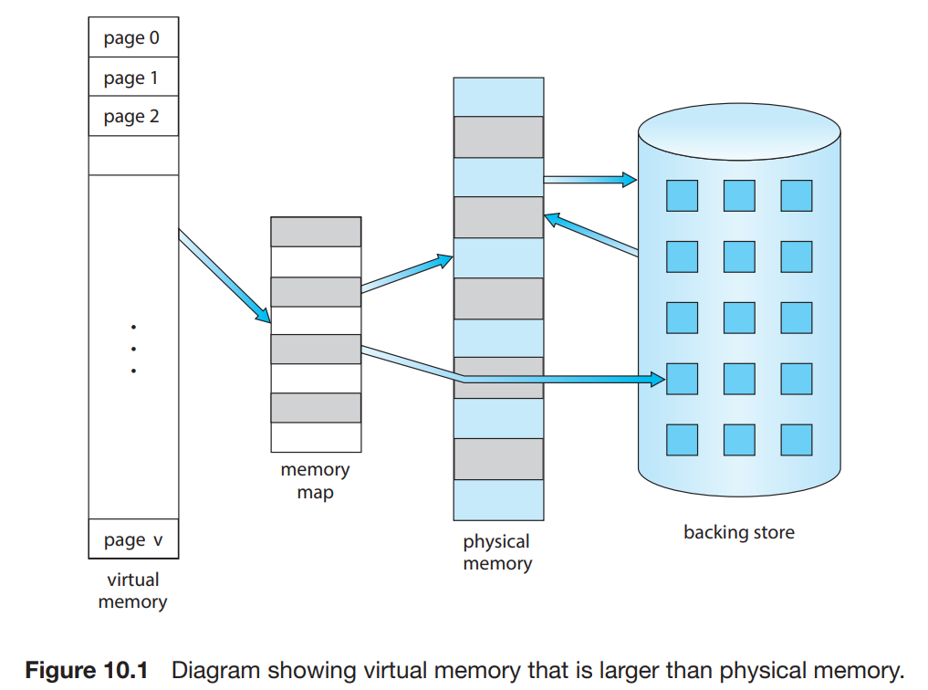

#### **The Virtual Address Space**

The **virtual address space** is the logical view of how a process is stored in memory. To the process, it appears as a single, contiguous space starting at address 0.

**(Refer to Figure 10.2 in your text)** Go to Figure 10.2. This shows the typical layout of a process's virtual address space in a Unix/Linux system:

- **Text:** The program's executable code (read-only).
- **Data:** The global and static variables.
- **Heap:** Dynamically allocated memory (via `malloc()` or `new`). It grows **upward** (toward higher addresses) as more memory is requested.
- **Stack:** Used for function call management, local variables, and return addresses. It grows **downward** (toward lower addresses) with each function call.

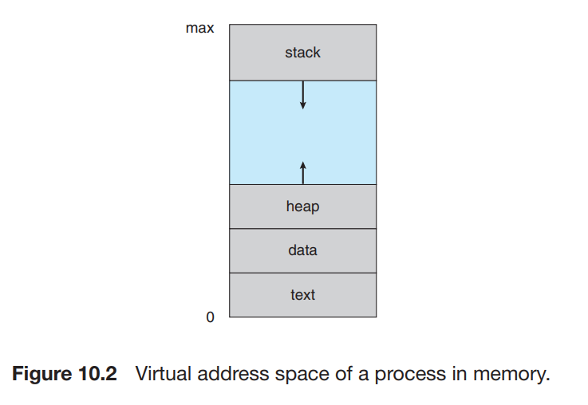

The large blank space between the heap and stack is unused virtual memory. It is part of the address space but consumes **no physical resources** unless the heap or stack grows into it. Address spaces with these unused gaps are called **sparse address spaces**. This sparsity is efficient and allows for flexible growth of segments and dynamic linking of libraries during execution.

#### **Sharing and Communication Enabled by Virtual Memory**

Beyond just enlarging the apparent memory, virtual memory enables powerful sharing features through **page sharing**:

1. **Sharing System Libraries:** Common libraries (like the standard C library `libc`) can be loaded into physical memory once. Then, the OS maps the *same physical pages* into the virtual address space of every process that uses that library.
   - **(Refer to Figure 10.3 in your text)** Go to Figure 10.3. It illustrates this beautifully. Two separate processes have their own private `text`, `data`, `heap`, and `stack`. However, the pages for the **shared library** are mapped to the *same physical page frames*. This saves tremendous amounts of memory.

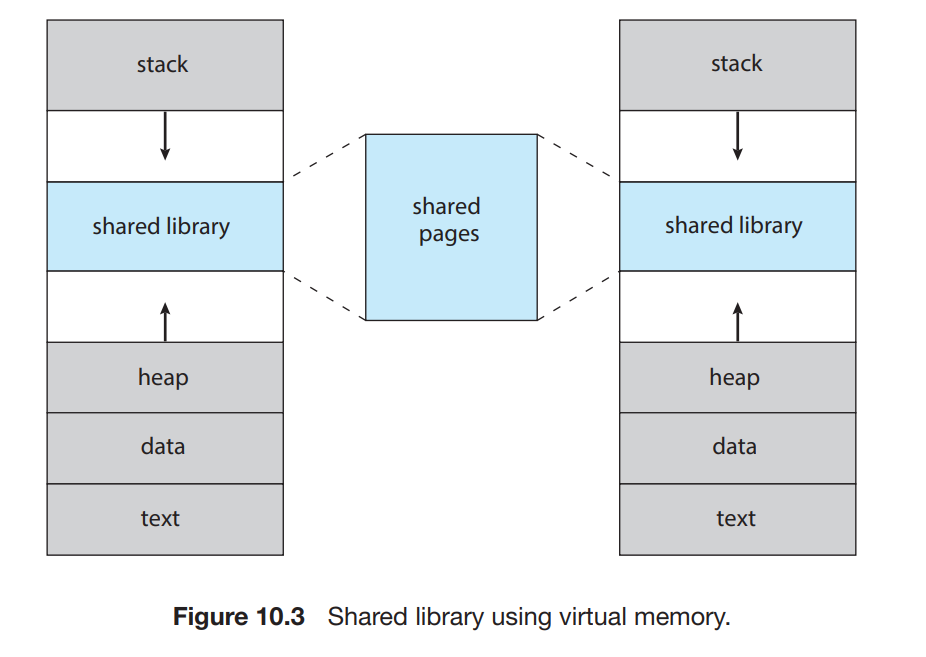

2. **Shared Memory for Inter-Process Communication (IPC):** Processes can create regions of memory intended explicitly for sharing. Each process maps this region into its own virtual address space, but behind the scenes, the OS points their mappings to the same set of physical pages. This provides a very fast method for processes to communicate (as discussed in Chapter 3).
3. **Fast Process Creation (`fork()`):** When a process creates a child using `fork()`, the OS can use a technique called **copy-on-write**. Instead of immediately duplicating all parent pages, it simply maps the child's virtual pages to the *same physical pages as the parent*, marking them as read-only. Only if either process tries to *modify* a page is a separate copy created. This makes `fork()` extremely fast and memory-efficient.

We will now explore the primary mechanism that makes all this possible: **demand paging**.

## **10.2 Demand Paging**

#### **Core Concept: Loading on Need, Not All at Once**

Imagine you have a massive encyclopedia program. At the start, it shows you a main menu with chapters like "Animals," "History," "Chemistry." The old way would be to load the entire encyclopedia—every single chapter—into your computer's physical RAM as soon as you double-click the icon, even though you might only ever read the "Animals" section.

- **Problem with the old way:** It's wasteful. It uses up precious, fast physical memory (RAM) for code and data that the program might never actually need during its current run. This slows down other programs and limits how many you can run at once.

#### **What is Demand Paging?**

Demand paging is the smarter, more efficient alternative. It's a fundamental technique used by all modern virtual memory systems.

- **Definition:** It is a strategy where **pages** of a program (chunks of its code and data) are **loaded into physical memory only when they are actually needed (or "demanded") during execution.**
- **How it works:** The program initially resides on the slower secondary storage (like your HDD or SSD). The operating system loads just the first page or two to get the program started (e.g., to show the main menu).
- **The "Demand" Trigger:** A page is "demanded" when the CPU tries to access an address that belongs to a page currently **not in physical RAM**. This access attempt causes a special interrupt called a **page fault**.

#### **Key Analogy and Connection**

Think of it like a paging system with swapping, but **more granular and proactive**. (Refer to Section 9.5.2 for background on swapping).

- In swapping, an entire process is moved between memory and disk.
- In demand paging, we swap **individual pages** in and out, and only do it **when the program explicitly needs that specific page.**

#### **The Primary Benefit**

This is a major reason why virtual memory is so powerful:

- **Efficient Memory Use:** Physical RAM is filled only with the pages that are **actively being used.** Pages that are never accessed (like the code for all the unselected menu options in the book's example) are never loaded. This allows the system to run more programs concurrently and makes much better use of available RAM.

#### **Crucial Terminology Recap**

- **Page:** A fixed-size block of a program's address space (e.g., 4 KB).
- **Frame:** A same-sized block of physical memory where a page can be loaded.
- **Page Fault:** The interrupt that occurs when a needed page is not in memory. This is the central event that triggers the demand-paging mechanism.
- **Secondary Storage (Backing Store):** Where all pages live when not in RAM (HDD, SSD, NVM device). Also called the **swap space** or **page file**.

### **10.2.1 Basic Concepts**

#### **The Two Homes for Pages**

In a demand-paging system, a process's pages live in one of two places at any given moment:

- **In Memory (Physical RAM):** Actively being used or recently used.
- **On Secondary Storage (Backing Store/ Swap Space):** The "waiting room" for all other pages.

Because of this split, the hardware and operating system need a clear way to know **where a specific page currently is**.

#### **Hardware Support: The Valid-Invalid Bit (Revisited)**

We use the same **valid-invalid bit scheme** from the page table (as discussed in Section 9.3.3), but with an expanded meaning.

- **Bit Set to "Valid" (e.g., 'v'):** This has the standard meaning. The associated page is:
  1. **Legal** (part of the process's logical address space).
  2. **Loaded in a frame** in physical memory. The page table entry contains the real physical frame number.
- **Bit Set to "Invalid" (e.g., 'i'):** This now has **two possible meanings**:
  1. **The page is not valid** (not part of the process's address space). Accessing it is a programming error.
  2. **The page is valid, but is currently located on secondary storage.** This is the new, crucial case for demand paging.

**Important Note:** Marking a page as "invalid" in this context has no performance cost **unless** the program actually tries to access it. It's just a note in the page table.

**Visualizing the Page Table (Go to Figure 10.4)**

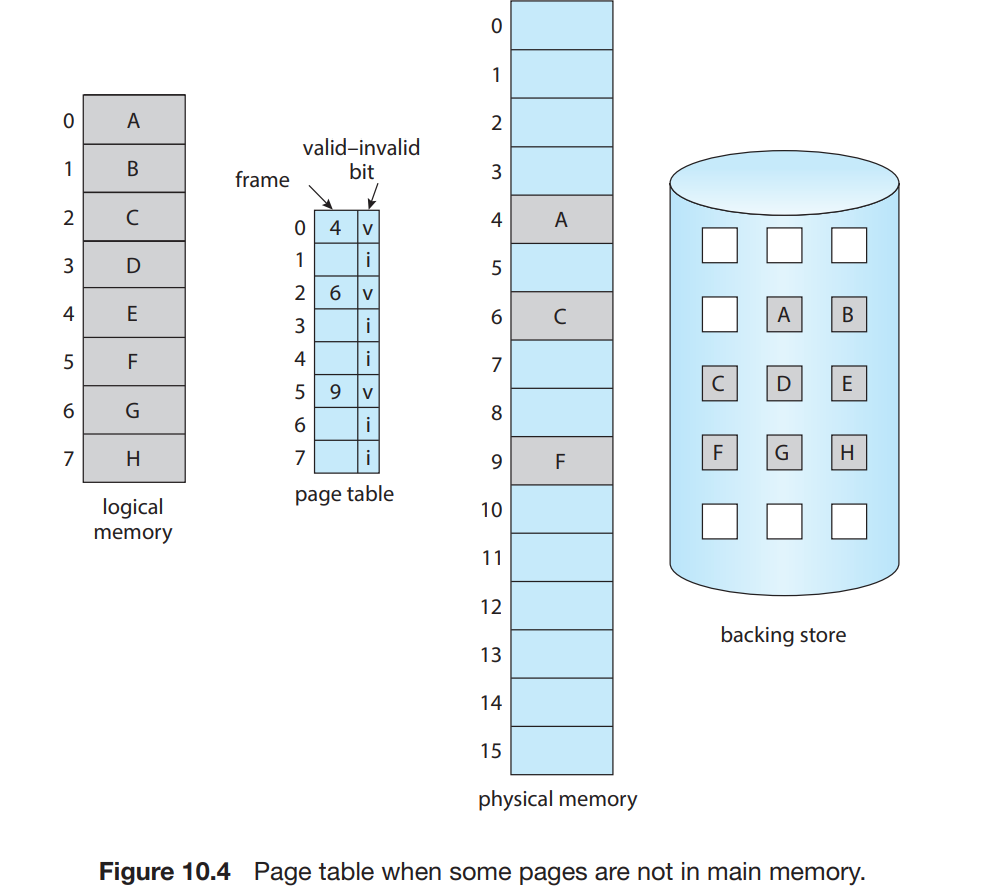

Look at Figure 10.4. It shows a process's page table and the corresponding physical memory.

#### **The Critical Event: Page Fault**

What happens when the CPU tries to access (read or write) an address in a page marked "invalid"?

1. The **paging hardware** (the MMU) consults the page table during address translation.
2. It sees the invalid bit is set.
3. It cannot complete the translation, so it **triggers a trap (an interrupt) to the operating system**. This specific trap is called a **page fault**.

**Handling a Page Fault: Step-by-Step (Go to Figure 10.5)**

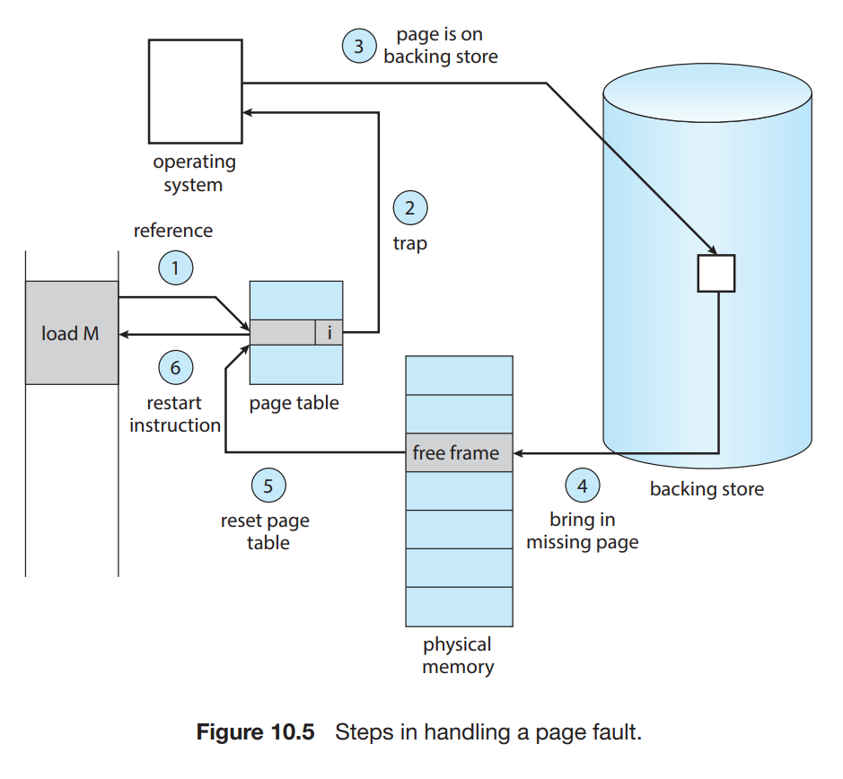

The OS follows a standard procedure to resolve the fault, make the page available, and resume the program transparently. Follow along with the numbered steps in Figure 10.5.

1. **Validate the Access:** The OS checks an internal table (part of the **Process Control Block - PCB**) for this process. It must determine: Was this memory reference to a **valid** page (just not in memory) or an **invalid** one (an illegal address)?
   - **If Invalid:** The process has a bug (e.g., accessing null/unallocated memory). The OS typically **terminates the process**.
   - **If Valid (but not in memory):** Proceed to step 2. This is the "demand paging" case.
2. **Locate the Page:** The OS now knows it needs to fetch page X from secondary storage.
3. **Find a Free Frame:** The OS takes a **free frame** from a system-wide list of available physical memory frames.
4. **Schedule Disk I/O:** The OS schedules a **disk read operation** to bring the desired page from the **backing store** into the newly allocated frame. This is a potentially slow, blocking operation. The process is put in a waiting state.
5. **Complete the I/O & Update Tables:** When the disk I/O completes:
   - The page's data is now in the physical frame.
   - The OS **modifies the process's page table entry** for this page:
     - Sets the valid-invalid bit to **`valid`**.
     - Writes the **physical frame number** into the entry.
   - The OS also updates its internal bookkeeping data structures.
6. **Restart the Instruction:** The OS must **roll back and restart the exact machine instruction that caused the page fault**. The CPU state is restored to just before the fault occurred. This time, when the instruction re-executes:
   - The page table entry is now **valid**.
   - The address translation succeeds.
   - The process accesses the memory location **as if the page had been there all along**. The process is completely unaware of the interruption.

#### **The Illusion**

This entire complex procedure is what creates the powerful **illusion of virtual memory**. To the process, it appears to have a vast, contiguous address space all readily available in fast memory. The OS and hardware work together behind the scenes to maintain this illusion by swapping pages between fast RAM and slow disk on an as-needed basis.

#### **Pure Demand Paging: The Extreme Starting Point**

The concept of demand paging can be taken to its logical extreme:

- **Initial State:** A process begins execution with **zero pages** loaded into physical memory. Its entire address space exists only on the secondary storage (swap space).
- **First Instruction Fault:** When the OS starts the process and sets the CPU's **instruction pointer (IP)** to the first instruction's address, that address resides in a page not in memory. This causes an immediate **page fault**.
- **Fault-Driven Loading:** The OS handles the fault, loads the required page (containing the startup code), and restarts the instruction. The process then executes, triggering a page fault **each and every time** it tries to access a new page (for code or data) for the first time.
- **Steady State:** Eventually, the process will have all the pages it actively needs loaded into memory. At this point, page faults stop (or become very rare), and the process runs efficiently. This ideal model is called **pure demand paging**: **a page is brought into memory only when a reference to it actually occurs.**

#### **Performance Concern: Could This Be Too Slow?**

A major theoretical concern arises:

- What if a single instruction itself **causes multiple page faults**? For example, an instruction might be long and cross a page boundary (fault for instruction page), and then it might read data from one page (second fault) and write results to another page (third fault).
- If every instruction required multiple slow disk operations, system performance would be **unacceptably poor**.

#### **The Savior: Locality of Reference**

Fortunately, real program execution exhibits a property called **locality of reference** (detailed in Section 10.6.1). This means:

- Programs tend to access memory in **clustered patterns**, not randomly.
- After accessing one memory location, the next access is very likely to be **nearby** (in the same page or adjacent pages).
- **Consequence for Paging:** Once a page is faulted into memory, many subsequent instructions and data accesses will be satisfied from that **same page** or recently used pages, leading to a high **hit rate**. The number of page faults per instruction is very low in practice, making demand paging viable.

#### **Hardware Requirements for Demand Paging**

The hardware needed is not new; it's the same as for standard paging and swapping, but used in a specific way:

1. **Page Table with Fault Detection:**
   - Must have a mechanism to mark an entry as **not resident in main memory**.
   - This is typically the **valid-invalid bit**, as discussed.
   - Alternatively, special **protection bits** (like a "present" bit) can serve the same purpose.
2. **Secondary Memory (Swap Space):**
   - This is the **backing storage** that holds all pages not currently in RAM.
   - **Device:** Usually a high-speed disk (HDD) or Non-Volatile Memory (NVM) device like an SSD.
   - **Terminology:**
     - **Swap Device:** The entire disk/NVM device used for this purpose.
     - **Swap Space:** The specific area (partition or file) on that device reserved for holding swapped-out pages.
   - **Management:** How the operating system allocates and manages this swap space is a critical topic covered in **Chapter 11**.

#### **Key Takeaway**

Demand paging relies on the interplay of:

- **Hardware (MMU, Page Table):** To detect when a needed page is absent (page fault).
- **Operating System (Fault Handler):** To perform the slow work of fetching the page from disk and updating tables.
- **Program Behavior (Locality):** To ensure that this fault-handling overhead is infrequent enough to maintain good performance, creating the successful illusion of a vast, fast virtual memory.

#### **A Crucial Requirement: Restarting Any Instruction**

##### **The Core Principle**

For demand paging to work transparently, the system must have a fundamental capability:

- **After handling a page fault, the operating system must be able to restart the interrupted instruction from the very beginning, in the exact same state, as if the fault never happened.** The *only* difference should be that the previously missing page is now in memory.

**How is this possible?** When the page fault trap occurs, the hardware **automatically saves the execution state** of the process (all registers, the condition codes, and crucially, the **instruction counter/program counter** pointing to the faulting instruction). This saved state allows the OS to restore and restart later.

##### **Restarting in Typical Cases**

For most simple instructions, restarting is straightforward:

- **Fault on Instruction Fetch:** The CPU hasn't even started the instruction. Restarting just means fetching it again from the same address (which is now accessible).
- **Fault on Operand Fetch:** The CPU fetched and decoded the instruction but faulted while trying to read the data it needs (the operand). To restart:
  1. Fetch the instruction again.
  2. Decode it again.
  3. Fetch the operand again (which will now succeed).

##### **A Detailed Walkthrough: The Three-Address ADD Instruction**

Consider the instruction: **`ADD A, B, C`** (Add contents of A to B, store result in C). Its execution involves multiple, distinct steps:

1. Fetch and decode the `ADD` instruction.
2. Fetch operand **A**.
3. Fetch operand **B**.
4. Perform the addition (A + B).
5. Store the result to location **C**.

**Scenario:** What if a page fault occurs **during step 5** because the page containing memory location **C** is not in RAM?

- The addition (step 4) has already been computed.
- The OS handles the fault: brings in the page for C, updates the page table.
- To restart, the OS reloads the saved state. The **instruction pointer points back to the `ADD` instruction**.
- The process must now execute the *entire* instruction again:
  - Re-fetch, re-decode `ADD`.
  - Re-fetch A and B.
  - Re-compute the sum.
  - Store to C (which now succeeds).
- **Analysis:** There is some repeated work (steps 1-4 are re-done), but it's less than one full instruction's worth of extra work. This overhead is acceptable because page faults are meant to be infrequent.

##### **The Major Difficulty: Instructions That Modify Multiple Locations**

The real architectural challenge comes from **complex instructions that can modify many memory locations** before completing. A classic example is the **IBM System 360/370 MVC (Move Character)** instruction, which copies a block of up to 256 bytes.

**The Problem:**

1. The instruction might **straddle page boundaries**. The source block or destination block might span two (or more) pages.
2. A page fault could occur **mid-operation**—after some bytes have already been copied, but before the instruction finishes.
3. If the source and destination blocks **overlap**, the partially completed move may have **already overwritten** some of the original source data. You cannot simply restart from the beginning because the source data is now corrupted.

##### **Architectural Solutions**

CPU architects have designed solutions to make such instructions "restartable." Two common strategies are:

1. **Pre-check and Validate Access Before Any Modification:**
   - The CPU's **microcode** (the low-level instruction logic) is designed to first **calculate and attempt to access the *start and end* addresses of both the source and destination blocks.**
   - If **any** of these required pages are not in memory, a page fault occurs **immediately, before a single byte is moved**.
   - After the OS resolves the fault and restarts the instruction, all pages are guaranteed to be present, and the move proceeds to completion without interruption.
2. **Use of Temporary Registers (Write-Back on Fault):**
   - As the instruction executes, if it needs to overwrite a memory location, it **first copies the old value into a hidden temporary register inside the CPU**.
   - It then writes the new value.
   - If a page fault occurs later in the instruction, the CPU's microcode **rolls back** by writing the saved old values from the temporary registers back to their memory locations.
   - This **restores memory to its exact state before the instruction began**, allowing a clean restart.

##### **Key Architectural Insight**

This discussion highlights a critical point:

- Paging is inserted as a layer **between the CPU and physical memory**.
- The goal is **complete transparency** to the software process.
- **While it's often assumed paging can be added to any system, this is only true for systems without demand paging** (where a missing page is just a fatal error).
- **Demand paging requires specific, careful CPU architectural support** to guarantee that any instruction can be interrupted by a page fault and later restarted without causing side effects or data corruption. The `MVC` example illustrates the non-trivial engineering required to make this work.

### **10.2.2 Free-Frame List**

#### **Purpose: The OS's Pool of Memory Frames**

A **free-frame list** is a fundamental operating system data structure. It is simply a **list (or pool) of physical memory frames that are currently unused and available for allocation.**

- **Why is it needed?** When a **page fault** occurs, the OS needs an empty physical frame to load the missing page into. Similarly, when a process's stack or heap grows, it needs new frames for the expanded segment.
- **Function:** The free-frame list is the **source** for these frames. It's the OS's "inventory" of ready-to-use physical memory.

#### **Visual Representation (Go to Figure 10.6)**

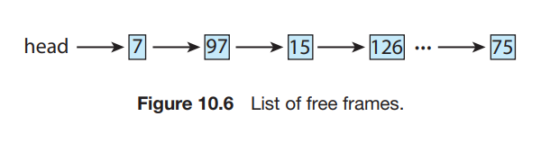

Figure 10.6 shows a simple linked-list representation of the free-frame list. Each node in the list contains the **frame number** of a free physical frame (e.g., frame 7, frame 97, etc.). The OS maintains a **head pointer** to track the next available frame.

#### **Frame Allocation Policy: Zero-Fill-on-Demand**

When the OS takes a frame from the free list and assigns it to a process, it cannot give the process whatever old data happens to be in that frame. This is a critical security and correctness requirement.

- **The Policy:** **Zero-fill-on-demand**. Before a frame is handed over to a process, the OS **ensures the entire frame is filled with zeros**.
- **Why is this essential?**
  1. **Security:** A frame previously used by one process might contain sensitive data (passwords, keys, documents). If reassigned without clearing, the new process could read this old data, causing a severe **information leak**.
  2. **Correctness:** The new process expects its memory to be initialized (often to zero). Random old data would cause unpredictable bugs.
- The "on-demand" part means the zeroing is done **at the time of allocation**, not necessarily beforehand. This avoids unnecessary work if the frame isn't used.

#### **Lifecycle of the Free-Frame List**

1. **System Startup:** When the OS boots, it identifies all physical memory not required for the kernel itself. **All these available frames are placed onto the free-frame list**. The list is at its maximum size.
2. **Normal Operation (Depletion):** As processes run and cause page faults or expand their segments, frames are **removed from the free list** and assigned. The free-frame list **shrinks**.
3. **Critical Threshold:** Eventually, the free-frame list will become empty or fall below a **low-water mark** (a minimum threshold set by the OS).
   - **Problem:** The next page fault cannot be satisfied because there is no free frame to load the new page into.
4. **Replenishment:** When the list is (near) empty, the OS must **repopulate** it. It does this by **freeing up frames that are currently in use** by selecting victim pages and writing them out to disk if modified. This process is known as **page replacement**.

**Next Step:** The strategies and algorithms for deciding *which frame to free* (the page-replacement policy) and handling the overall memory pressure are the central topics of **Section 10.4**.

### **10.2.3 Performance of Demand Paging**

Demand paging is not free. It introduces a massive performance penalty when a page fault occurs, and the overall system performance depends almost entirely on **how often** these faults happen.

#### **1. The Effective Access Time Formula**

We measure the impact using **Effective Access Time (EAT)**—the average time it takes for the CPU to access a memory location, factoring in both normal accesses and page faults.

- **`ma` = Memory Access Time** (when the page is in RAM). Example: **10 - 200 nanoseconds**.
- **`p` = Probability of a Page Fault** (0 ≤ p ≤ 1). We want this to be **very close to 0**.
- **Page Fault Time** = The total time to service a single page fault (can be **milliseconds**).

The formula is a weighted average: **Effective Access Time = (1 – p) × ma + p × (Page Fault Time)**

This shows that the overall speed is dominated by the page fault rate (`p`) because `Page Fault Time` is **enormous** compared to `ma`.

#### **2. Anatomy of a Page Fault (The Source of the Delay)**

A page fault is not a simple disk read. It's a complex sequence of software and hardware operations:

**Sequence of Events During a Page Fault:**

1. **Trap to OS:** CPU interrupt.
2. **Save Process State:** Save registers, program counter, etc.
3. **Diagnose Fault:** OS determines this interrupt was a page fault.
4. **Validate & Locate:** Check if the address is legal. Find where the needed page is on disk.
5. **Issue I/O Request:** Request to read the page into a free frame.
   - a. **Queue Wait:** Wait in line for the disk.
   - b. **Seek & Latency:** Disk head moves and waits for the right sector (the **slowest part**).
   - c. **Data Transfer:** Page is read into memory.
6. **CPU Reallocation (Optional but Crucial):** While waiting for the **very slow I/O** (steps 5a-5c), the OS **suspends the faulting process and gives the CPU to another ready process**. This maintains **CPU utilization** (multiprogramming).
7. **I/O Completion Interrupt:** Disk signals the read is done.
8. **Save Other Process State:** If step 6 happened, save the state of the process currently on the CPU.
9. **Diagnose I/O Interrupt:** OS determines this interrupt is from the disk for the page-in request.
10. **Update Tables:** Correct the page table and OS data structures to show the page is now in memory.
11. **Wait for CPU:** The original process waits in the ready queue to get the CPU back.
12. **Restore & Resume:** Restore the process's saved state (from step 2) and restart the faulting instruction.

**Three Major Components of Page-Fault Service Time:**

1. **Service the page-fault interrupt** (Steps 1-4, 10): Software overhead in the OS kernel. Can be **1–100 microseconds** with good coding.
2. **Read in the page** (Step 5): The **dominant cost**. **Device service time** (seek, latency, transfer). For a traditional HDD, this is ~**8 milliseconds (8,000,000 ns)**.
3. **Restart the process** (Steps 11-12): Context-switch and resume overhead. Also **1–100 microseconds**.

**Important:** The **8 ms** figure is for the disk *service time* only. If the disk is busy, **queueing delay** adds even more time.

#### **3. The Staggering Performance Impact (Numerical Example)**

Let's plug in realistic numbers to see the devastating effect of even a low page-fault rate.

- Assume: `ma = 200 ns`, `Page Fault Time = 8 ms = 8,000,000 ns`.
- Formula becomes: **EAT = (1-p) × 200 + p × 8,000,000 = 200 + 7,999,800 × p**

**Scenario A: 1 fault per 1,000 accesses (p = 0.001)**

- EAT = 200 + 7,999,800 × 0.001 = 200 + 7,999.8 ≈ **8,200 ns (8.2 microseconds)**.
- **Slowdown Factor:** 8,200 ns / 200 ns = **41 times slower**.

**Scenario B: Acceptable Slowdown (10% or less)**

- We want EAT ≤ 220 ns (a 10% increase from 200 ns).
- Solve: 220 ≥ 200 + 7,999,800 × p
- 20 ≥ 7,999,800 × p
- **p ≤ 0.0000025**
- **Interpretation:** To keep performance degradation under 10%, **fewer than 1 memory access in 399,990 can cause a page fault.**

**CONCLUSION:** **The page-fault rate (`p`) must be kept EXTREMELY low** for demand paging to be viable. This is why **page-replacement algorithms (Section 10.4)** and the principle of **locality** are so critical.

#### **4. Swap Space vs. File System: Where to Page From?**

The backing store for pages can be the **swap space** or the original **executable file**.

- **Swap Space I/O is Faster** than regular file system I/O because:
  - It uses **larger blocks**.
  - No **file metadata lookups** (directory, inode) or complex **indirect allocation** is needed. (See Chapter 11).

**Strategies for Using Backing Store:**

1. **Copy Entire File to Swap at Startup:**
   - **Process:** At program launch, copy all pages from the executable file into the swap area.
   - **Pro:** All subsequent paging is fast (from swap).
   - **Con:** Slow startup, wastes time/space copying pages that may never be used.
2. **Demand Page from File, Write-Back to Swap (Linux/Windows Hybrid):**
   - **Process:** Initially, page faults are serviced by reading pages directly from the executable file.
   - **Key Twist:** When a **dirty** page (one that has been modified) is chosen for replacement, it is written **to swap space**, not back to the original read-only file.
   - **Result:** All **subsequent** requests for that modified page come from the faster swap space. This is a **practical and common compromise**.
3. **Demand Page from File Only (for Code/Read-Only Sections):**
   - Used for **binary executable code pages**, which are **never modified**.
   - **Process:** These pages are paged in directly from the file system.
   - On replacement, they can be **simply discarded (overwritten)** because a clean copy exists on disk. If needed again, re-read from the file.
   - **Swap space is still required** for **anonymous memory**—pages not associated with a file, like a process's **stack and heap** (which are private and modifiable). Linux and BSD use this approach.

#### **5. Special Case: Mobile Systems**

As noted in Section 9.5.3, most mobile OS (iOS, Android) **do not support traditional swapping to a dedicated swap area.**

- **Why?** Limited flash memory write cycles and focus on app responsiveness/ battery.
- **Their Strategy:**
  - Demand-page **read-only pages (code)** directly from the app's executable file.
  - Under memory pressure, **reclaim (discard) clean, read-only pages**. They can be reloaded from the file later.
  - For **anonymous memory** (stack/heap), iOS **never reclaims** it unless the app quits or voluntarily frees it. Android and others may use **compressed RAM** (Section 10.7) as a faster alternative to swapping to flash storage.

**OVERARCHING GOAL:** Regardless of the strategy, the system must **minimize the page-fault rate (`p`)** to maintain performance. The choice of backing store and paging strategy is an engineering trade-off between speed, storage wear, and implementation complexity.

## **10.3 Copy-on-Write**

#### **Motivation: Optimizing Process Creation with `fork()`**

A major performance challenge in operating systems is the **`fork()` system call**, which creates a new (child) process as a duplicate of the parent.

- **The Naive Approach:** The traditional implementation of `fork()` physically copies the parent's entire address space (all pages) into new frames for the child. This is **expensive in time and memory**.
- **The Common Reality:** In many cases (like in a shell), the child process immediately calls **`exec()`** after `fork()` to replace its memory image with a new program. The costly copy of the parent's space is **immediately discarded**, making it completely unnecessary waste.

**Solution:** Use **Copy-on-Write (COW)**, a clever optimization that defers copying until absolutely necessary.

#### **How Copy-on-Write Works**

The core idea is to **share pages initially and only make private copies if/when either process tries to modify them.**

**Initial Setup (After `fork()` with COW):**

1. Instead of copying pages, the OS makes the child's page table point to the **same physical frames** as the parent.
2. All these now-shared pages are marked as **read-only** in the page tables of **both** parent and child.
3. The OS also marks them internally as **copy-on-write** in its bookkeeping data.

**Trigger Event (The "Write"):** When either the parent or the child attempts to **write** to a shared COW page:

1. The **hardware** detects a write attempt to a read-only page and generates a **protection fault** (similar to a page fault).
2. The **OS trap handler** identifies this as a copy-on-write fault (not a normal page fault).
3. The OS then:
   - Allocates a **new free frame** from the free-frame list.
   - **Copies the contents** of the original shared page into this new frame.
   - **Maps the faulting process's page table entry** to this new copy, and changes the permission for that entry to **read-write**.
   - Leaves the other process's mapping (to the original page) unchanged and still read-only.
4. The OS then restarts the faulting instruction, which now executes successfully on the **private copy**.

**Visual Guide (Go to Figures 10.7 and 10.8):**

- **Figure 10.7 (Before Modification):** Shows two processes sharing physical pages A, B, and C. Page C is marked copy-on-write (implied by the sharing).

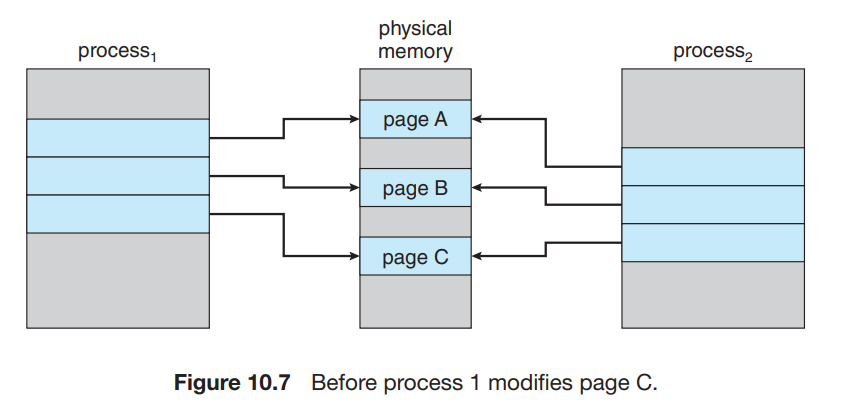

- **Figure 10.8 (After Process 1 Modifies Page C):** Process 1 now has its own private **copy of page C**. Process 2 still points to the original page C. The shared pages A and B remain shared, as they were not modified.

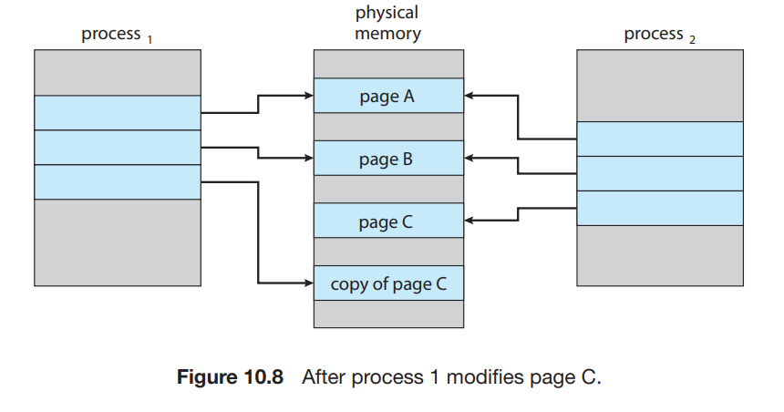

#### **Key Benefits and Details**

- **Efficiency:** Only modified pages are copied. All unmodified pages (like large sections of program code) remain shared, saving significant memory and copy time.
- **What Needs to be COW?** Only **modifiable pages** (data, stack, heap) need the COW protection. **Read-only pages** (like executable code) can be safely shared forever and never need copying.
- **Widespread Use:** This optimization is standard in modern OSes like **Windows, Linux, and macOS**.

#### **Special Case: The `vfork()` System Call**

UNIX systems offer an even more extreme optimization called **`vfork()`**.

- **How it works:** `vfork()` creates the child process **without any page duplication or COW setup**. The child process **borrows the parent's entire address space** temporarily, and the **parent is suspended**.
- **Critical Danger:** The child operates directly on the parent's memory. Any modification the child makes is **immediately visible to the parent** when it resumes. This can easily cause corruption if not handled correctly.
- **Strict Usage Rule:** `vfork()` is **only safe** if the child **immediately calls `exec()` or `_exit()`**. `exec()` replaces the address space, and `_exit()` terminates, so no long-term sharing occurs.
- **Purpose & Efficiency:** It is designed for the classic "fork-and-exec" pattern where a shell launches a command. It is **extremely fast** because it avoids **all** page table and frame management overhead at creation time. It is sometimes used to implement shell interfaces.

**Summary:** **Copy-on-Write** is a lazy-evaluation technique for memory management that optimizes `fork()` by sharing pages and copying only on a write attempt. **`vfork()`** is a more dangerous, non-lazy alternative used for maximum speed in specific, controlled scenarios.

## **10.4 Page Replacement**

#### **The Context: Memory Over-Allocation**

Our previous analysis assumed a page is loaded once and stays in memory. But to use memory efficiently, operating systems intentionally **over-allocate** memory—they allow the total size of all active processes' working sets to exceed the available physical RAM.

#### **The Inevitable Problem: Running Out of Free Frames**

Over-allocation works until the combined demand spikes.

**The Crisis Point:** When a **page fault occurs** and the OS goes to the free-frame list to bring in the needed page, it discovers **the list is empty. All frames are in use.**

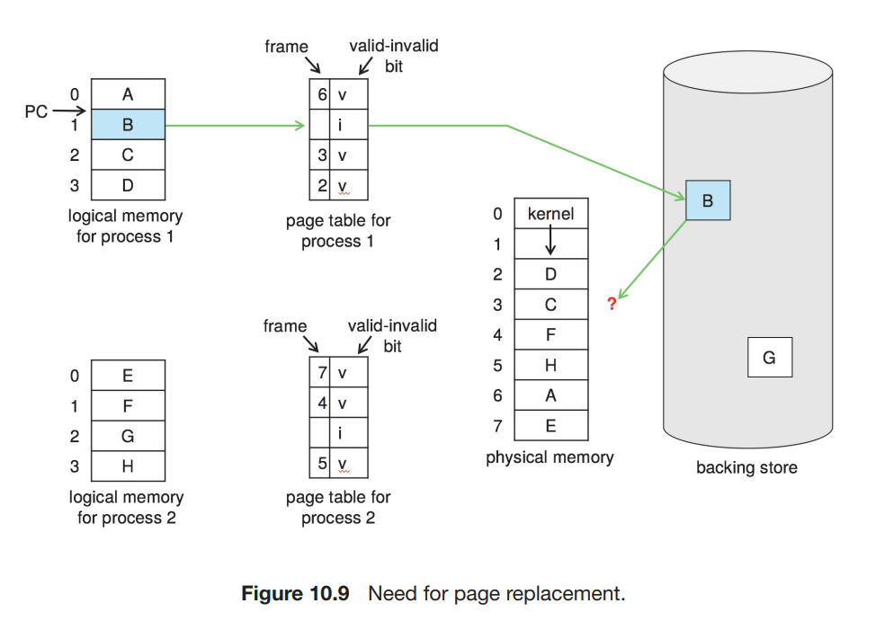

#### **Possible OS Responses to No Free Frames**

1. **Terminate the Faulting Process:**
   - **Why it's bad:** Demand paging's goal is transparency and efficiency. Crashing a process because the system is over-committed breaks the illusion of abundant memory and is unfair to the user. **This is not an acceptable solution.**
2. **Swap Out an Entire Process (Traditional Swapping):**
   - **Action:** Move one entire process's pages to disk, freeing all its frames.
   - **Drawback:** This reduces the **degree of multiprogramming**. More critically, as discussed in **Section 9.5**, copying entire processes is **too slow and inefficient** for modern systems with large address spaces. **This method is largely obsolete.**

#### **The Standard Solution: Page Replacement**

The modern, universal approach is to combine swapping and paging at the **page granularity**.

- **Core Idea:** When no free frame exists, the OS **selects a victim frame** that is currently in use by some process. It **frees this victim frame** to serve the new page fault. This is a two-step process:
  1. **Find a "victim" page** currently in memory. Decide which one to evict using a **page-replacement algorithm**.
  2. **Free the victim's frame:**
     - If the victim page is **clean** (not modified since being loaded), it can simply be **overwritten** (its copy on disk is still valid).
     - If the victim page is **dirty** (modified), it must first be **written back to disk (swapped out)** to save its contents, *then* its frame can be reused.

**This is the fundamental technique.** The remainder of this section will detail the algorithms and intricacies of choosing the victim page effectively.

### **10.4.1 Basic Page Replacement**

#### **The Core Algorithm**

When a page fault occurs and **no free frame is available**, the OS must execute the **page-replacement algorithm**. The goal is to free a frame that is currently in use so it can be given to the faulting page.

**The Page-Replacement Process (Follow along with Figure 10.10):**

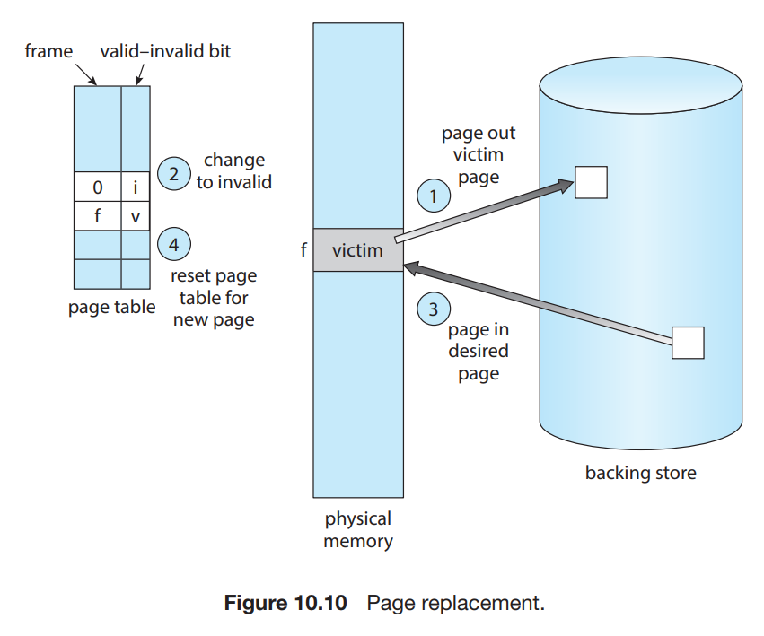

1. **Locate Desired Page:** OS determines the disk address of the needed page.
2. **Find a Free Frame:**
   - **a.** If the **free-frame list** has a frame, use it. Go to step 3.
   - **b.** If **no free frame exists (the "?" in Figure 10.9)**, use a **page-replacement algorithm** to select a **victim frame** currently held by some process.
   - **c.** **Free the Victim Frame:**
     - Check if the victim page is **dirty** (modified). If yes, **schedule a write (page-out)** of the victim page's contents to the swap space/backing store.
     - Update the victim page's page table entry, marking it as **invalid** and **not resident**.
     - The frame is now considered free.
3. **Page-In:** **Read the desired page** from disk into the newly freed frame. Update the faulting process's page table to mark the page **valid** and point to this frame.
4. **Restart:** Resume execution of the faulting process from the interrupted instruction.

**Crucial Note:** If a victim page must be written out, the page fault now requires **two disk I/O operations**: one **write** (page-out) and one **read** (page-in). This **doubles the page-fault service time**, severely impacting performance.

#### **Performance Optimization: The Modify (Dirty) Bit**

To minimize this double-I/O penalty, hardware provides a **modify bit (or dirty bit)** in each page table entry (or TLB entry).

- **How it works:** The CPU's memory management hardware **automatically sets this bit to 1** whenever the process performs a **write** operation to any location within that page.
- **Use during Page Replacement:** When selecting a victim, the OS checks its dirty bit.
  - **If Dirty Bit = 1:** The page has been modified. Its copy on disk is **stale**. The OS **must write** the page back to disk (**page-out**) before freeing its frame.
  - **If Dirty Bit = 0:** The page is **clean**. The copy in memory is identical to the copy on disk. The OS can simply **discard** the page (overwrite the frame) **without any disk write**. The required disk I/O is just the **page-in**.

**Impact:** This can **halve the I/O time** for a page fault if the victim page is clean. This is especially beneficial for **read-only pages** (like program code), which are always clean and can be discarded instantly.

#### **The Illusion Completed: Logical vs. Physical Memory Separation**

Page replacement is the final piece that completes the powerful illusion of virtual memory.

- **Without Demand Paging:** The logical address space can be larger than physical memory, but **all pages of a running process must still be in RAM**.
- **With Demand Paging + Page Replacement:** This constraint is **removed**. The size of a process's logical address space is **no longer limited by physical memory**.
  - **Example:** You can run a 20-page process on a system with only 10 physical frames.
  - **How?** Only 10 pages reside in memory at any instant. When the process needs an 11th page, the page-replacement algorithm selects one of the current 10 as a victim, swaps it if needed, and loads the new page. The process can access a virtual address space much larger than physical RAM.

#### **The Two Fundamental Design Problems**

To make this work efficiently, OS designers must solve two interrelated problems:

1. **Frame-Allocation Algorithm:** When there are **multiple processes** in memory, how do we **distribute the available physical frames** among them?
   - Do we give each process an equal number? Or proportional to its size? Or based on its priority?
2. **Page-Replacement Algorithm:** When a page fault occurs and we need a free frame, **which specific page should we select as the victim?**
   - The goal is to choose the victim such that future page faults are minimized.

**Why These Algorithms Are Critical:** Disk I/O is **extremely slow** (milliseconds) compared to memory access (nanoseconds). Therefore, even a **small improvement** in the hit rate of these algorithms (reducing the number of page faults) leads to a **massive gain in overall system performance**. The following sections will explore specific algorithms for page replacement.

#### **Evaluating Page-Replacement Algorithms**

Many different page-replacement algorithms exist, each with its own strategy for selecting a victim. The primary metric for comparing them is: **Goal: Choose the algorithm that yields the lowest page-fault rate.**

We evaluate algorithms by simulating their behavior on a recorded sequence of memory accesses.

#### **The Reference String**

To test an algorithm, we use a **reference string**—a sequence of memory accesses generated by a process.

- **How to get it:** You can either:
  1. Generate one artificially (e.g., using a random-number generator).
  2. **Trace a real system** and record every memory address accessed (this produces massive data—millions per second).
- **Data Reduction - Two Key Simplifications:**
  1. **Focus on Page Numbers:** For a fixed page size (e.g., 4KB), we only care about the **page number**, not the full address. The offset within the page is irrelevant for replacement decisions.
  2. **Remove Consecutive Duplicates:** If a page is referenced multiple times in a row, only the **first reference** can cause a page fault. Subsequent back-to-back references will always find the page already in memory. We compress these consecutive duplicates into a single entry in the reference string.

**Example of Generating a Reference String:** Raw address sequence (in decimal, assuming 100-byte pages): `0100, 0432, 0101, 0612, 0102, 0103, 0104, 0101, 0611, 0102, 0103, 0104, 0101, 0610, 0102, 0103, 0104, 0101, 0609, 0102, 0105`

1. **Convert to Page Numbers:** Divide each address by page size (100).
   - 0100 / 100 = Page 1
   - 0432 / 100 = Page 4
   - 0101 / 100 = Page 1
   - ... and so on.
   - Intermediate result: `1, 4, 1, 6, 1, 1, 1, 1, 6, 1, 1, 1, 1, 6, 1, 1, 1, 1, 6, 1, 1`
2. **Remove Consecutive Duplicates:** Collapse runs of the same page number.
   - Final reference string: **`1, 4, 1, 6, 1, 6, 1, 6, 1, 6, 1`**

#### **The Impact of Available Frames**

The performance of any algorithm depends critically on the **number of page frames (`m`)** available in physical memory.

- **More Frames = Fewer Faults:** As you increase `m`, the page-fault rate decreases. There's more room to keep pages, so fewer replacements are needed.
- **Example with our string (`1,4,1,6,1,6,1,6,1,6,1`):**
  - **With 1 frame:** Every new page reference forces a replacement. **Faults = 11.**
  - **With 3 frames:** Can hold pages 1, 4, and 6 simultaneously after the first few faults. **Faults = 3** (first access to pages 1, 4, and 6 only).
- **The Curve (Go to Figure 10.11):** The relationship is not linear. The graph shows **number of page faults** (y-axis) vs. **number of frames** (x-axis). The curve drops sharply at first, then levels off to a minimum. Adding more physical memory (more frames) moves you right on this curve, reducing faults.

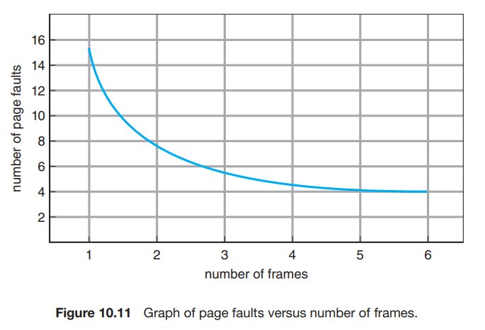

#### **Standard Test Setup**

To compare algorithms side-by-side, we will use a **common reference string** and a fixed, small number of frames. This creates a constrained scenario where replacement decisions matter.

- **Reference String for Examples:**  
  `7, 0, 1, 2, 0, 3, 0, 4, 2, 3, 0, 3, 2, 1, 2, 0, 1, 7, 0, 1`
- **Number of Frames:** `3`
- We will analyze how different algorithms process this string and count their resulting page faults.

### **10.4.2 FIFO Page Replacement**

#### **The Algorithm: First-In, First-Out**

The **FIFO (First-In, First-Out)** page-replacement algorithm is the simplest to understand and implement. It treats the set of pages in memory like a queue.

- **Rule:** When a page must be replaced, select the **oldest** page—the one that has been in memory the longest.
- **Implementation:** Maintain a **FIFO queue** of all pages currently in memory.
  - When a page is loaded into a frame, insert it at the **tail** (end) of the queue.
  - When replacement is needed, remove the page at the **head** (front) of the queue for eviction.

#### **Example Execution (Follow Figure 10.12)**

Let's trace the algorithm with our standard test: Reference string = `7, 0, 1, 2, 0, 3, 0, 4, 2, 3, 0, 3, 2, 1, 2, 0, 1, 7, 0, 1` and **3 frames**.

The table (Figure 10.12) shows the contents of the 3 frames after each reference. A page fault (F) triggers a load or a replacement.

| Step | Ref | Frame Contents (Queue: Head -> Tail) | Fault? | Notes |
| --- | --- | --- | --- | --- |
| 1 | 7 | [7] | F | Load 7. Queue: 7 |
| 2 | 0 | [7, 0] | F | Load 0. Queue: 7, 0 |
| 3 | 1 | [7, 0, 1] | F | Load 1. Queue: 7, 0, 1 |
| 4 | 2 | **[2**, 0, 1] | F | **Replace oldest (7)** with 2. Queue: 0, 1, **2** |
| 5 | 0 | [2, 0, 1] | - | 0 is already in memory. |
| 6 | 3 | [2, **3**, 1] | F | **Replace oldest (0)** with 3. Queue: 1, 2, **3** |
| 7 | 0 | [2, 3, **0**] | F | **Replace oldest (1)** with 0. Queue: 2, 3, **0** |
| 8 | 4 | [**4**, 3, 0] | F | **Replace oldest (2)** with 4. Queue: 3, 0, **4** |
| ... | ... | ... | ... | ... (Continues as per figure) |

**Total Page Faults with FIFO and 3 frames = 15.**

#### **Pros and Cons of FIFO**

- **Advantage:** Extremely simple to implement (just a queue).
- **Disadvantage:** **Performance is often poor** because it ignores the **usage pattern**.
  - It might evict an **old but frequently used** page (like a common variable), causing an immediate extra page fault to bring it back.
  - It might keep a **new but unused** page just because it was loaded recently.

**Important:** Even a bad choice doesn't cause incorrect execution—it just hurts performance by increasing the fault rate.

#### **The Shock: Belady's Anomaly**

FIFO exhibits a counter-intuitive and problematic behavior known as **Belady's Anomaly**.

- **What it is:** For the FIFO algorithm, **increasing the number of frames can sometimes lead to an *increase* in the number of page faults.**
- **Normal Expectation:** More memory (more frames) should always result in fewer or equal page faults. (See the general curve in **Figure 10.11**).
- **FIFO's Violation:** The curve for FIFO (shown in **Figure 10.13**) is **not always decreasing**. It can have bumps where it goes up.

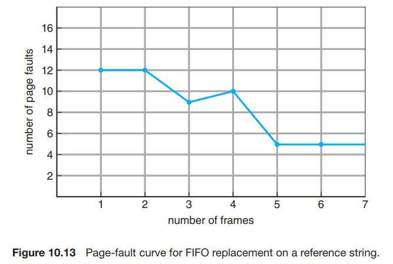

**Example from the text:** Reference string: `1, 2, 3, 4, 1, 2, 5, 1, 2, 3, 4, 5`

- With **3 frames**: **9 page faults**.
- With **4 frames**: **10 page faults** *(More frames, more faults!)*.

**Why this happens:** The order of eviction in FIFO depends entirely on arrival time, not on future need. Adding a frame can change the sequence of pages in the queue in a way that accidentally ejects a page that will be needed again very soon, while a smaller set might have retained it.

**Significance:** Belady's Anomaly shows that FIFO is not a robust algorithm. A good page-replacement algorithm should guarantee that more frames never result in more faults (the **stack property**). FIFO fails this test.

### **10.4.3 Optimal Page Replacement**

#### **The Ideal Algorithm: Look into the Future**

The discovery of Belady's Anomaly prompted the question: What is the **best possible** page-replacement algorithm? This ideal algorithm is called **OPT** (Optimal) or **MIN** (Minimum).

- **Rule:** When a page must be replaced, select the page **whose next use will occur farthest in the future.** In other words, replace the page you will need **the longest time from now**.
- **Result:** This algorithm **guarantees the lowest possible page-fault rate** for any given number of frames and any reference string. It also **never suffers from Belady's Anomaly** (more frames never cause more faults).

#### **Example Execution (Follow Figure 10.14)**

Let's trace OPT with our standard test: Reference string = `7, 0, 1, 2, 0, 3, 0, 4, 2, 3, 0, 3, 2, 1, 2, 0, 1, 7, 0, 1` and **3 frames**.

The table (Figure 10.14) shows the frame contents. The key is that OPT makes decisions based on **future knowledge** of the reference string.

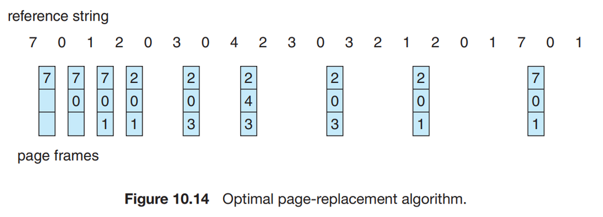

**Total Page Faults with OPT and 3 frames = 9.**

**Performance Comparison:** OPT's **9 faults** is vastly better than FIFO's **15 faults**. If we ignore the first three compulsory faults that every algorithm must incur, OPT has **6 faults** vs. FIFO's **12 faults**—OPT is **twice as good**. This is the **gold standard**.

#### **The Major Limitation: Unrealizable**

OPT is **not implementable in a real, general-purpose operating system**.

- **Why?** It requires **perfect future knowledge** of the entire reference string—i.e., knowing exactly which pages a process will access and in what order, *before* it happens.
- **Analogy:** This is similar to the **Shortest-Job-First (SJF)** CPU scheduling algorithm (Section 5.3.2), which also requires knowing the future (burst times).

#### **Practical Use: A Benchmark for Comparison**

Because OPT is unimplementable, its real value is as a **theoretical benchmark**.

- Researchers and OS designers use it to evaluate **real, practical algorithms**.
- **Example Metric:** "Our new algorithm produces, at worst, 12.3% more page faults than OPT, and on average only 4.7% more."
- By measuring how close a real algorithm gets to OPT, we can understand its efficiency and quality.

**Conclusion:** OPT defines the limit of what is possible. All real page-replacement algorithms are attempts to **approximate OPT's behavior** using only **past information and heuristics**, without needing a crystal ball.

### **10.4.4 LRU Page Replacement**

#### **The Concept: Using the Recent Past to Predict the Near Future**

Since the optimal (OPT) algorithm is impossible to implement (it needs future knowledge), we need a feasible approximation. The key insight:

- **OPT looks forward:** Replaces the page used farthest in the **future**.
- **FIFO looks at load time:** Replaces the page loaded **longest ago**.
- **LRU (Least Recently Used) approximation:** Uses the **recent past** as a predictor. It assumes that pages heavily used in the **recent past** will likely be used again in the **near future**. Therefore, it protects them.

**Rule:** When a page must be replaced, LRU selects the page that **has not been used for the longest period of time**. It replaces the **least recently used** page.

**Interesting Theoretical Note:** If you reverse a reference string (`S` becomes `S_R`), the page-fault rate of **OPT** on `S` equals **OPT** on `S_R`. Similarly, **LRU** on `S` equals **LRU** on `S_R`. This symmetry highlights LRU as "OPT looking backward in time."

Tracing LRU with our standard test: Reference string = `7, 0, 1, 2, 0, 3, 0, 4, 2, 3, 0, 3, 2, 1, 2, 0, 1, 7, 0, 1` and **3 frames**.

We must now track the **order of last use** for pages in memory.

| Step | Ref | Frame Contents (LRU Order: Most Recent -> Least Recent) | Fault? | Reasoning for Replacement |
| --- | --- | --- | --- | --- |
| 1 | 7 | [7] | F | Load. |
| 2 | 0 | [0, 7] | F | Load 0. Now 0 is most recent, 7 is least recent. |
| 3 | 1 | [1, 0, 7] | F | Load 1. Order: 1 (newest), 0, 7 (oldest). |
| 4 | 2 | [2, 1, 0] | F | Need a frame. **LRU page is 7** (last used at step 1). Evict 7, load 2. New order: 2, 1, 0. |
| 5 | 0 | [0, 2, 1] | - | **Hit on 0.** Reorder: Access 0 moves it to front. New order: 0 (newest), 2, 1 (oldest). |
| 6 | 3 | [3, 0, 2] | F | Need a frame. **LRU page is 1**. Evict 1, load 3. New order: 3, 0, 2. |
| 7 | 0 | [0, 3, 2] | - | **Hit on 0.** Reorder: 0 moves to front. Order: 0, 3, 2. |
| 8 | 4 | [4, 0, 3] | F | Need a frame. **LRU page is 2**. Evict 2, load 4. New order: 4, 0, 3. |
| 9 | 2 | [2, 4, 0] | F | Need a frame. **LRU page is 3**. Evict 3, load 2. New order: 2, 4, 0. |
| ... | ... | ... | ... | ... (Continue as per Figure 10.15) |

**Total Page Faults with LRU and 3 frames = 12.**

**Performance:** LRU (12 faults) is much better than FIFO (15) though not as good as OPT (9). It's a **good practical approximation**.

#### **Major Challenge: Implementing LRU**

The LRU policy is excellent, but implementing it **efficiently requires significant hardware support**. We need to track the order of *every single memory reference*.

**Two Theoretical Implementation Methods:**

1. **Counters (Time-of-Use Stamp):**
   - Each page-table entry has a **time-of-use field**.
   - The CPU has a **logical clock/counter** that increments on **every memory reference**.
   - **On each memory access** (read or write), the current clock value is **copied into the time-of-use field** for the referenced page.
   - **On replacement:** The OS must **scan all page-table entries** in memory to find the page with the **smallest time stamp** (least recently used).
   - **Overheads:**
     - A write to the page table in memory on **every access** (very expensive).
     - A full table scan on every page fault.
     - Clock overflow must be handled.
2. **Stack (Doubly Linked List):**
   - Maintain a **stack of page numbers** (not a software LIFO stack, but an ordered list).
   - **On a page reference:** That page is **removed from its current position** in the stack and **placed on the top** (made most recent).
   - **Structure:** Best implemented as a **doubly linked list** with head (most recent) and tail (least recent) pointers.
   - **Operation:** Moving a page from the middle to the top requires updating up to **6 pointers**, but it's a constant-time operation (`O(1)`).
   - **Replacement:** The **tail pointer** always points to the **LRU page**—instant identification, no search needed.
   - This method is suitable for **microcode or firmware** implementation.

**Crucial Hardware Requirement:** Both methods **must update their data structures on *every* memory reference**. Doing this via software interrupts would slow down each memory access by an order of magnitude (e.g., 10x), which is **unacceptable**. Therefore, **direct hardware support** (like dedicated registers, counters, or microcode) is essential, making pure LRU rare in its exact form.

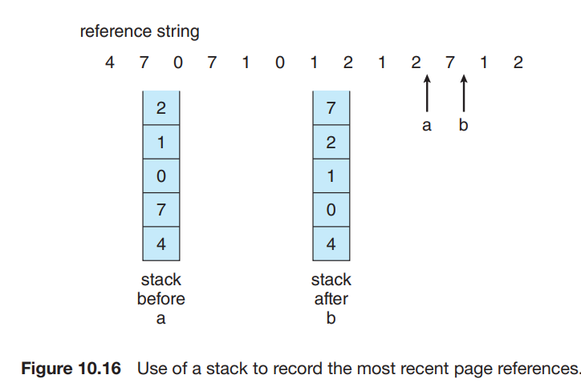

#### **Stack Algorithms and Belady's Anomaly**

LRU shares a vital property with OPT: it **does not suffer from Belady's Anomaly**.

- **Reason:** Both are **stack algorithms**.
- **Stack Algorithm Property:** The set of pages in memory for `n` frames is **always a subset** of the set of pages that would be in memory with `n+1` frames.
- **For LRU:** The pages in memory are the `n` **most recently referenced** pages. If you add a frame (`n+1`), you simply keep one more of the most recent pages. You never lose a page you had before.
- **Consequence:** With a stack algorithm, **increasing the number of frames never increases the page-fault rate**. The fault curve (like Fig. 10.11) is always non-increasing.

### **10.4.5 LRU-Approximation Page Replacement**

##### **The Reality: Limited Hardware Support**

Few computer systems provide the full hardware needed for **exact LRU** (counters or stack updating on every memory access). Many systems provide only minimal support, forcing the use of simpler algorithms like FIFO. However, a common middle ground is the **reference bit**.

- **What is a Reference Bit?** A single bit stored in each **page table entry** (or in a separate hardware array).
- **Hardware Action:** The memory management unit (MMU) hardware **automatically sets this bit to 1** whenever the corresponding page is referenced (read from or written to).
- **Initial State:** The operating system clears all reference bits to 0 periodically.
- **Information Gained:** The reference bit tells us **whether a page has been used recently (1) or not (0)**, but it provides **no information about order**—we can't tell *which* of two pages with bit=1 was used more recently.

This limited data is the foundation for algorithms that **approximate LRU** behavior.

#### **10.4.5.1 Additional-Reference-Bits Algorithm**

To get a crude sense of usage history over time, we can extend the single reference bit into a **history of reference bits**.

**How it works:**

1. **Data Structure:** For each page, the OS maintains an **8-bit byte** (or similar length) in a table in memory. Think of it as a **shift register**.
2. **Timer Interrupt:** At regular intervals (e.g., every 100 milliseconds), a timer interrupt gives control to the OS.
3. **Recording History:** For each page, the OS performs a **shift operation** on its 8-bit register:
   - The **current hardware reference bit** (1 or 0) is shifted into the **leftmost (high-order) bit** of the register.
   - All existing bits are shifted one position to the **right**.
   - The **rightmost (low-order) bit** is discarded.
4. **Interpretation:** After many intervals, this 8-bit register holds a **history of the reference bits** for the last 8 time periods.
   - **Example Register Values:**
     - `00000000`: Page not referenced in the last 8 periods. **Very cold.**
     - `11111111`: Page referenced in *every* recent period. **Very hot.**
     - `11000100`: Page used recently (leftmost bits=1) and also some time ago, but with gaps. **Warmer than `01110111`** because its most recent history (left side) shows more recent use.

**Selecting a Victim for Replacement:**

- Treat each 8-bit register as an **unsigned integer** (0 to 255).
- The page with the **smallest numerical value** is considered the **least recently used** (it has the fewest recent references).
- **Tie-Breaking:** If multiple pages have the same lowest value, the OS can either replace **all of them** or use a secondary rule (like **FIFO**) to pick one.

**Trade-Off:**

- **More bits** provide a longer, more detailed history but increase per-page memory overhead and update time.
- **Fewer bits** make the update faster but give a less accurate history.

**The Extreme Case (1-bit history):** If we reduce the history length to zero, we are left with **only the current reference bit**. This special case is so important it has its own name: the **Second-Chance page-replacement algorithm**, which we will cover next. It's the simplest practical LRU approximation.

#### **10.4.5.2 Second-Chance Algorithm (The Clock Algorithm)**

This is a practical and widely-used approximation of LRU that requires only a **single reference bit** per page.

##### **Basic Idea: FIFO with a Second Chance**

The foundation is a **FIFO queue**, but we use the reference bit to grant a reprieve.

1. **FIFO Selection:** Start by considering the page at the **head** of the FIFO queue (the oldest page).
2. **Inspect Reference Bit:**
   - **If Reference Bit = 0:** This page hasn't been used recently. It gets **no second chance**. **Evict it immediately.**
   - **If Reference Bit = 1:** This page *has* been used since the last check. **Give it a second chance:**
     - **Clear its reference bit to 0.**
     - **Move it to the tail of the queue** (updating its "arrival time" to now).
3. **Repeat:** Move to the next page in the queue and repeat step 2 until you find a page with reference bit = 0 to evict.

**Important Behaviors:**

- A page that is **continuously used** will keep its reference bit set to 1 and will **never be evicted** (it always gets a second chance).
- If **all pages have reference bit = 1**, the algorithm will make a full cycle, clearing all bits, and then replace the original head page (which now has bit=0). In this full-cycle case, it **degenerates to pure FIFO**.

##### **Circular Queue Implementation (The Clock Analogy)**

The algorithm is best visualized and implemented as a **circular queue** (a "clock" face with a moving hand).

- **Data Structure:** All pages in memory are arranged in a **circular list**. A **clock hand (pointer)** points to the next candidate for inspection.
- **Procedure (Follow Figure 10.17):**
  - **(a) Initial State:** Hand points to a page. We need a free frame.
  - **Scan:** Check the reference bit of the page under the hand.
    - If **bit = 1**: **Clear the bit to 0** and **advance the hand** to the next page.
    - If **bit = 0**: This is the **victim**. Select this page for replacement.
  - **(b) After Scanning:** The hand has advanced, clearing bits (setting them to 0) as it passed pages with bit=1.
  - **Replacement:** Replace the victim page, insert the new page into the victim's position in the circular list, and **advance the hand to the next position**.

**Why "Clock"?** The hand sweeps around the circular list like a clock's hand, giving pages a "second chance" if they've been used (bit=1).

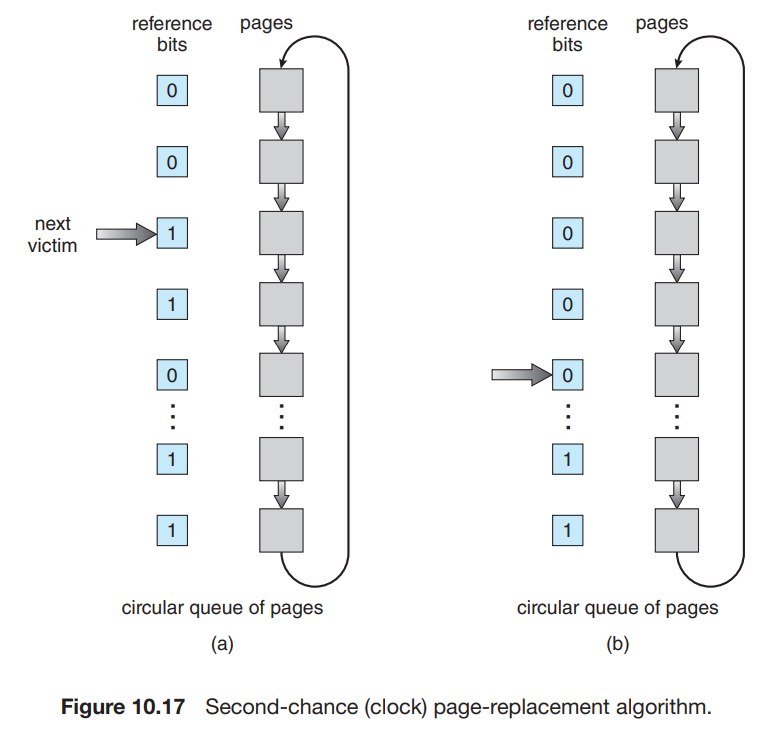

#### **10.4.5.3 Enhanced Second-Chance Algorithm**

This is a significant improvement that considers both **usage** and **modification** to minimize costly disk writes.

**We now use two bits per page:**

1. **Reference Bit (`R`)**: As before (1 = used recently, 0 = not).
2. **Modify (Dirty) Bit (`M`)**: (1 = page has been modified, 0 = clean).

This creates **four ordered classes** `(R, M)`:

| Class | `(R, M)` | Meaning | Priority to Replace |
| --- | --- | --- | --- |
| 1 | `(0, 0)` | **Not recently used, Not modified** (Clean and cold). Best victim. | **Highest (Best)** |
| 2 | `(0, 1)` | **Not recently used, But modified** (Dirty but cold). Good victim, but requires a write-back (page-out). | **Second Best** |
| 3 | `(1, 0)` | **Recently used, Clean** (Hot but clean). Likely to be used again soon. | Third |
| 4 | `(1, 1)` | **Recently used, Modified** (Hot and dirty). Very likely to be used again and requires write-back. | **Lowest (Worst)** |

##### **The Enhanced Algorithm (Multi-Pass Clock)**

The algorithm works like the clock algorithm but makes **multiple passes** looking for the best class.

1. **Start** with the clock hand at its current position.
2. **Scan the circular list.** For each page, examine its `(R, M)` class.
   - The goal is to find the **first page in the lowest non-empty class**.
3. **First Pass:** Look for a `(0, 0)` page (ideal victim). If found, replace it.
4. **Second Pass (if needed):** If no `(0, 0)` exists, make another scan looking for a `(0, 1)` page. **During this scan, do NOT clear the R bit.** We are only looking for pages that have remained unreferenced (`R=0`) since the first pass. If found, replace it (but must write it to disk first).
5. **Third/Fourth Pass:** If necessary, continue scanning for `(1, 0)` and finally `(1, 1)`. If all pages are `(1,1)`, the algorithm will eventually select one after a full cycle (effectively becoming FIFO among dirty pages).

**Key Advantage:** This algorithm **actively prefers clean pages over dirty ones** to avoid the expensive disk write operation, while still respecting recent usage. It's a very effective balance and is used in real systems (a variant is known as the **Not Recently Used (NRU)** algorithm).

### **10.4.6 Counting-Based Page Replacement**

These algorithms try to make decisions based on the **frequency** of page accesses rather than (or in addition to) recency.

#### **Least Frequently Used (LFU)**

- **Rule:** Replace the page that has been **used the least number of times** (has the smallest reference count).
- **Rationale:** A page that is accessed frequently is important and should stay in memory.
- **Major Problem: Staleness.** A page might be used intensively during an initialization phase (giving it a high count) and then never used again. LFU will keep this **no-longer-needed page** in memory because of its historically high count, while evicting a newer, more actively used page with a lower count.
- **Partial Solution: Aging.** To make counts reflect recent usage, periodically **shift all counts right by 1 bit** (divide by 2). This creates an **exponentially decaying average**. Older references fade away, giving more weight to recent activity.

#### **Most Frequently Used (MFU)**

- **Rule:** Replace the page with the **largest reference count**.
- **Counterintuitive Rationale:** The argument is that the page with the **smallest count** was probably just brought in and **hasn't had a chance to be used yet**, so it might be needed soon. Conversely, a page with a very high count has already been used heavily and might not be needed immediately.
- **This logic is generally considered flawed** for typical program behavior (locality suggests recently used pages will be used again).

**Verdict on Counting Algorithms:** Neither LFU nor MFU is common in practice.

- **Implementation Cost:** Requires maintaining and updating counters for every page access, which is expensive.
- **Poor Approximation of OPT:** They don't model the "future need" principle of OPT as effectively as LRU-based approximations do.

### **10.4.7 Page-Buffering Algorithms**

These are **supplemental techniques** used to **improve the performance** of *any* core page-replacement algorithm (like FIFO, LRU, or Clock). They focus on optimizing I/O and reducing the latency felt by the faulting process.

#### **1. Free-Frame Pool with Immediate Restart**

- **Standard Problem:** If the victim page is dirty, the process must wait for a **page-out** (write) to complete **before** the needed page can be **page-in** (read). This sequential I/O doubles the wait time.
- **Buffering Solution:** Always maintain a **pool of free frames**.
- **Procedure on a page fault:**
  1. Select a victim page using your main algorithm (LRU, Clock, etc.).
  2. **Immediately take a free frame from the pool** and **initiate the page-in** of the desired page into this free frame.
  3. **In parallel**, write the dirty victim page out to disk (page-out).
  4. Once the page-in completes, the process can **restart immediately**.
  5. When the page-out completes, the victim's frame is added **back to the free pool**.
- **Benefit:** The process only waits for the **page-in** time. The page-out I/O happens concurrently in the background. This **hides the write latency**.

#### **2. List of Modified Pages (Clustering of Writes)**

- **Goal:** Increase the chance that a selected victim is **clean**, avoiding the write-back altogether.
- **Method:** The OS maintains a list of pages that have been modified (dirty).
- **Background Daemon:** When the **paging disk is idle**, this daemon selects pages from the dirty list, writes them out to disk in batches, and **clears their modify bits** (making them clean).
- **Benefit:** When the page-replacement algorithm later needs a victim, many pages will already be clean and can be **instantly overwritten**. This also **clusters writes** (multiple pages written in one efficient disk operation), which is much faster than writing single pages sporadically.

#### **3. Free-Frame Pool with Page Cache**

- **Enhanced Free Pool:** Don't just keep free frames empty. **Remember which page used to be in each frame** in the free pool.
- **Why?** If a process faults on a page that was recently evicted, and that page's frame is still in the free pool (with its contents intact because it was clean or hasn't been reused), you can **reassign it immediately without any disk I/O**.
- **Procedure on a page fault:**
  1. First, **scan the free-frame pool** to see if the desired page is already there (a **soft fault** or **reclaim**). If found, just re-link it to the process's page table. **Zero I/O.**
  2. If not in the pool, then proceed with the normal page-replacement routine (select victim, use a free frame, perform disk I/O).
- **Benefit:** This acts as a **second-chance cache in memory**, salvaging incorrect victim choices. It's especially useful with algorithms like the simple **Second-Chance/Clock**, which can sometimes evict a page that is needed again soon.

**Real-World Use:** Variants of these buffering techniques are used in many systems. For example, some UNIX versions combine the **Second-Chance algorithm** with a **free-frame cache**. Section 10.5.3 will discuss these and other optimizations further.

### **10.4.8 Applications and Page Replacement**

#### **The Problem: When OS Generalization Fails**

The operating system's virtual memory and page-replacement algorithms (like LRU) are designed as **general-purpose** solutions. They assume typical application behavior (locality of reference). However, for **specialized applications with unique, predictable access patterns**, this one-size-fits-all approach can **hurt performance**.

#### **Case Study 1: Database Management Systems (DBMS)**

- **How Databases Work:** A DBMS like PostgreSQL or Oracle has its own sophisticated **memory manager** and **I/O buffer pool**. It knows exactly which data pages (from tables, indexes) are "hot" or "cold" based on query patterns.
- **Double Buffering Problem:**
  1. The **DBMS** reads a data page from disk into its own **application buffer** in memory.
  2. The **Operating System**, unaware of the DBMS's structures, also takes that data and may store it in the **OS page cache** (another copy in memory).
- **Result:** The same disk block exists **twice in RAM**—once in the DBMS buffer, once in the OS cache. This wastes memory that could be used to cache more data.
- **Solution:** Many databases use **Direct I/O** or similar mechanisms to bypass the OS page cache, reading data directly from disk into the application's own buffers, avoiding duplication.

#### **Case Study 2: Data Warehouses & Large Sequential Scans**

- **Typical Workload:** Read a massive dataset sequentially (e.g., a multi-gigabyte table), perform analysis/aggregation, then write results.
- **Why LRU is Terrible Here:**
  - LRU treats the **most recently used (newest)** pages as most important.
  - In a sequential scan, **old pages** (the ones read earlier) are **not needed again** until the *next full scan*. The "new" pages are the ones just read.
  - LRU will **evict the old pages** and **keep the new ones**, which is exactly the **opposite** of what's needed if you plan to loop back and start the scan over. You want to keep the *oldest* pages (the start of the dataset) because you'll re-read them soon.
- **Irony:** In this specific pattern, the **MFU (Most Frequently Used)** algorithm—which is generally poor—might outperform LRU! Why? The first pages of the dataset are accessed at the start of *every* scan, giving them a very high frequency count. MFU would keep these high-count pages, which is beneficial for a looping sequential scan.

#### **The OS Escape Hatch: Raw I/O**

For applications that need full control, some operating systems offer a **raw disk** interface.

- **What it is:** A **raw disk** (or raw partition) is a section of secondary storage presented to the application as a **simple, linear array of logical blocks**, with **no file system structure** (no inodes, directories, file names, etc.).
- **Raw I/O:** The application performs I/O directly to this raw partition. This operation **bypasses** all OS file services:
  - **File I/O Demand Paging**
  - **File Locking**
  - **Prefetching**
  - **Space Allocation**
  - **Naming and Directory Lookup**
- **Benefit:** The application has complete control over caching, read-ahead, and data layout. It can implement an access pattern perfectly suited to its task.
- **Major Drawback:** The application takes on massive complexity—it must implement all the services a file system provides (crash consistency, space management, etc.). **This is only viable for highly specialized, complex software like databases.**

#### **Key Takeaway**

There is a **fundamental tension** between:

1. **OS Generalization:** Providing transparent, convenient, safe virtual memory and file services for all applications.
2. **Application Specialization:** Allowing performance-critical, knowledgeable applications to manage their own memory and I/O for optimal efficiency.

Most applications benefit greatly from the OS's services. But for a critical few, the OS mechanisms can be a bottleneck, necessitating features like **Direct I/O** or **Raw I/O** to relinquish control.

## **10.5 Allocation of Frames**

#### **The Core Question**

We now move from deciding *which page to replace* to deciding *how many frames to give to each process*. If the system has a pool of free frames, how should we distribute them among competing processes?

#### **The Simplest Strategy: Global Allocation from a Free List**

Consider a system with 128 physical frames. The OS itself might use 35 for kernel code and tables, leaving **93 free frames** for user processes.

- **Initial State:** All 93 user frames are on the **free-frame list**.
- **Process Start:** A user process begins and causes page faults.
- **Allocation:** The first **93 page faults** are satisfied by simply taking frames from the free list. No replacement is needed yet.
- **After Exhaustion:** On the **94th page fault**, the free list is empty. Now the **page-replacement algorithm** must be invoked to select a victim frame from among the **93 frames already allocated to this same process**, free it, and then load the new page.
- **Process Termination:** When the process ends, all its frames are returned to the free-frame list.

**Variations on this theme:**

- The OS can allocate its own buffers from the free list too, allowing unused OS memory to temporarily support user paging.
- Maintain a **small reserve** (e.g., 3 frames) on the free list to handle a page fault immediately while a replacement victim is being selected and written out in the background.

**Key Point of Simple Strategy:** Frames are allocated on-demand from a **global pool**. The process doesn't have a fixed, guaranteed allocation; it competes for all free frames until memory is full, and then it competes with itself (through its own page replacement).

### **10.5.1 Minimum Number of Frames**

We cannot allocate frames arbitrarily. There is both a **lower bound** (minimum) and an **upper bound** (maximum) for the frames a process must/can have.

#### **Why a Minimum? Two Reasons:**

1. **Performance:** Too few frames lead to an excessively high page-fault rate, crippling performance (thrashing, discussed later).
2. **Correctness:** An **instruction must be able to complete execution** after a page fault is resolved. This requires enough frames to hold all the distinct pages a single instruction might reference.

#### **Architectural Minimum: Ensuring Instructions Can Restart**

The CPU architecture dictates the **absolute minimum** number of frames. The requirement stems from the need to **restart any instruction** after a page fault (as discussed in Section 10.2.1).

**Let's build examples:**

- **Case 1: Simple Single-Address Instruction**
  - Instruction: `LOAD R1, A` (Load from memory address `A` into register R1).
  - This instruction references:
    1. The **instruction itself** (page `P_instr`).
    2. The **operand** at address `A` (page `P_A`).
  - **Minimum frames required: 2.** One for the code page, one for the data page. If you had only 1 frame, a page fault for either component would evict the other, making restart impossible.
- **Case 2: Adding One Level of Indirect Addressing**
  - Instruction: `LOAD R1, (A)` (Load from the address *pointed to* by the contents of memory location `A`).
  - This can reference:
    1. The **instruction** (page `P_instr`).
    2. The **indirect word** at address `A` (page `P_A`).
    3. The **final operand** at the address stored in `A` (page `P_final`).
  - All three could be on different pages.
  - **Minimum frames required: 3.** Try with 2 frames: If `P_instr` and `P_A` are in memory, and a fault occurs for `P_final`, you'd have to evict one of them. If you evict `P_instr`, you cannot restart. If you evict `P_A`, you lose the pointer needed to find the operand. **Deadlock.**
- **Case 3: Complex Instructions (e.g., IBM MVC)**
  - Instructions that modify multiple memory locations (like block moves) may require even more frames to guarantee a safe, restartable state, as their microcode might need to pre-access all source and destination pages.
- **Case 4: Modern x86-64 Architecture**
  - Intel/AMD architectures are generally **register-to-register** or **register-to-memory**. They don't allow direct memory-to-memory operations in a single instruction. This **limits the potential memory references per instruction**, keeping the **architectural minimum low (often 2)**.

#### **Summary of Frame Limits**

- **Minimum Number of Frames:** Defined by the **computer architecture** to ensure instruction restartability. It's a hard lower limit.
- **Maximum Number of Frames:** Defined by the **total available physical memory** (minus OS needs).
- **The Allocation Challenge:** The interesting design space for the OS is in the **wide range between this minimum and maximum**. How do we decide on a fair and efficient allocation within this range? This leads to **allocation algorithms**.

### **10.5.2 Allocation Algorithms**

We need a policy to decide how many frames (`a_i`) to give to each process `P_i`. Let:

- `m` = Total number of **available free frames** (for user processes).
- `n` = Number of **competing processes**.

#### **1. Equal Allocation**

The simplest approach: divide the frames equally among all processes.

- **Formula:** `a_i = floor(m / n)` for each process.
- **Leftover Frames:** Any remainder frames (`m mod n`) are kept as a **global free-frame buffer pool**.
- **Example:** 93 frames, 5 processes.
  - Each gets: `93 / 5 = 18` frames.
  - Leftover: `93 mod 5 = 3` frames go to the free pool.
- **Problem:** It ignores process needs. A small 10-page process gets the same allocation as a massive 1000-page process. This is **inefficient**—the small process wastes unused frames, while the large process may suffer excessive page faults.

#### **2. Proportional Allocation**

Allocate frames in proportion to each process's size (its **virtual memory demand**). The idea is to give a larger share to bigger processes.

- **Definitions:**
  - `s_i` = Size of process `P_i` (in **pages**, not bytes).
  - `S` = Sum of all process sizes = `Σ s_i`.
- **Formula:** `a_i = (s_i / S) * m`
- **Adjustments:** The result `a_i` must be:
  1. Rounded to an **integer**.
  2. **At least** the architectural **minimum** number of frames.
  3. The sum of all `a_i` must be `≤ m`.
- **Example from text:** Two processes. `m = 62` frames.
  - Process 1: `s_1 = 10` pages.
  - Process 2: `s_2 = 127` pages.
  - `S = 10 + 127 = 137` pages.
  - Allocation:
    - `a_1 = (10 / 137) * 62 ≈ 4.53 → **4 frames**`
    - `a_2 = (127 / 137) * 62 ≈ 57.47 → **57 frames**`
    - Total: 4 + 57 = 61 frames. The 1 leftover frame goes to a free pool.
- **Advantage:** More "fair" in terms of need. The large process gets more resources to accommodate its working set.
- **Dynamic Adjustment:** In both equal and proportional schemes, the allocation **changes when the multiprogramming level (`n`) changes**.
  - **New process arrives:** Frames are taken from existing processes (each loses a few) to give to the newcomer.
  - **Process terminates:** Its freed frames are redistributed among the remaining processes.

#### **3. Priority-Based Allocation**

Both equal and proportional allocation treat all processes as equal. But we often have **high-priority** and **low-priority** processes.

- **Goal:** Give more memory to high-priority processes to **speed up their execution**, even if it means slowing down low-priority ones.
- **How:** Modify the proportional allocation formula to use **priority** as a weight instead of (or in addition to) size.
  - **Simple Priority Scheme:** `a_i` is proportional to the process's priority value.
  - **Combined Scheme:** `a_i` is proportional to `(s_i * priority_i)` or a similar combined metric.
- **Effect:** A small, high-priority process could receive more frames than a large, low-priority one, ensuring it runs with fewer page faults and completes faster.

### **10.5.3 Global versus Local Allocation**

This section addresses a critical design choice: **When a process needs a free frame, where can it look for a victim page?**

#### **Local Replacement**

- **Definition:** Each process can only select a victim page **from among the frames currently allocated to itself**.
- **Consequence:** The **number of frames allocated to a process (`a_i`)** **remains constant**. The process competes only with itself.
- **Advantage:**
  - **Predictable Performance:** A process's page-fault rate depends **only on its own behavior**. It is insulated from the memory pressure caused by other processes.
  - **Isolation:** One greedy process cannot starve others by stealing their frames.
- **Disadvantage:**
  - **Potential Inefficiency:** Memory can become **fragmented**. A process with low memory activity cannot lend its unused frames to a process that desperately needs them. Overall system throughput may suffer.

#### **Global Replacement**

- **Definition:** A process can select a victim page **from the set of all frames in the system, regardless of which process owns them**.
- **Consequence:** The **number of frames allocated to a process is dynamic**. A process can gain frames by taking them from others, and lose frames if others take from it.
- **Example with Priorities:** A system could implement a policy where a **high-priority process can take frames from low-priority processes**, but not vice-versa. This directly enforces priority-based allocation.
- **Advantage:**
  - **Higher System Throughput:** Memory is a **global resource** that flows to the processes that are **most active at any given moment**. This generally leads to better overall utilization and performance.
- **Disadvantage:**
  - **Unpredictable Performance:** A process's performance becomes dependent on the **"paging behavior of other processes"**. The same program could run fast when the system is idle and very slow when memory is under heavy contention from other processes.

**Verdict:** **Global replacement is more common** in practice because it achieves higher overall throughput, which is usually the system-wide goal.

#### **Implementing Global Replacement: The Reaper Daemon with Thresholds**

A common practical strategy for global replacement doesn't wait for the free-frame list to hit zero. Instead, it uses **background reclamation** based on **watermark thresholds**.

**The Mechanism (Follow Figure 10.18):**

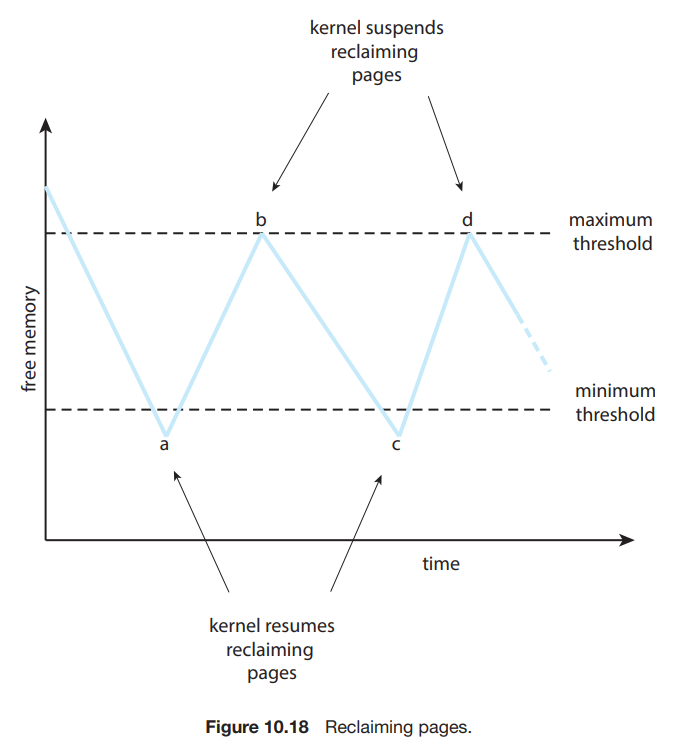

- **Two Thresholds:**
  1. **Minimum Threshold (Low-Water Mark):** The free memory level below which the system is considered under memory pressure.
  2. **Maximum Threshold (High-Water Mark):** The target free memory level to reach after reclamation.
- **Reaper Daemon (Pageout Daemon):** A kernel routine that runs periodically or when triggered.
- **Operation Cycle:**
  1. **Normal Operation (a->b):** At point **a**, free memory falls **below the minimum threshold**. This triggers the **reaper daemon**.
  2. **Reclamation Phase:** The daemon **aggressively scans all user processes** (excluding kernel) using a page-replacement algorithm (often a **clock/LRU approximation**) to select victim pages. It writes out dirty victims and adds their frames to the free list.
  3. **Suspension (b):** Reclamation continues until free memory reaches the **maximum threshold** at point **b**. The daemon then suspends.
  4. **Repeat (c->d):** As processes run, free memory drains again. At point **c**, it drops below the minimum, and the cycle repeats (c->d).

#### **Escalation Under Severe Memory Pressure**

What if the reaper can't keep up and free memory keeps falling **dangerously low**?

- **Tactic 1: More Aggressive Reclamation:** Switch the reaper algorithm from a polite one (like Second-Chance) to a more aggressive one (like pure **FIFO**), reclaiming pages faster.
- **Tactic 2: The Nuclear Option - OOM Killer (Linux Example):** In extreme cases, the OS may **terminate a process** to free all its memory instantly.
  - **How Linux Chooses a Victim Process:** Each process has an **OOM score**. The score increases with:
    - **Percentage of total memory used** (biggest factor).
    - Process priority (lower priority → higher score).
    - Other heuristics (e.g., long-running vs. new).
  - The **OOM Killer** selects a high-scoring process and kills it. You can view a process's score in `/proc/<pid>/oom_score`.

#### **Configurability**

- The **threshold values** (min/max) can often be tuned by a system administrator based on total physical memory and workload characteristics.
- The **aggressiveness** of the reaper and the OOM killer's policies can also be adjusted.

**This hybrid approach—background reclamation with thresholds—provides the benefits of global replacement (high throughput) while maintaining a buffer of free memory to handle sudden demands and allowing controlled escalation under extreme pressure.**

#### **Extra: Major and Minor Page Faults**

##### **The Distinction**

While all page faults occur when a process accesses a page without a valid mapping, operating systems classify them based on the **work required to resolve them**. This distinction helps in performance monitoring and analysis.

- **Major Page Fault (Hard Fault - Windows):**
  - **When it happens:** The desired page is **not in physical memory (RAM)** at all. It resides **only on the backing store** (disk/swap).
  - **Resolution Cost:** **High**. Requires a **physical disk I/O operation**:
    1. Find a free frame (may involve page replacement).
    2. **Read the page from disk** into the frame.
    3. Update the page table.
  - **Associated With:** True **demand paging**. A high rate of major faults indicates the process is actively bringing its working set into memory or is under memory pressure (thrashing).
- **Minor Page Fault (Soft Fault - Windows):**
  - **When it happens:** The desired page **is already in physical memory**, but the **process's page table lacks a valid mapping** to it. **No disk I/O is needed.**
  - **Causes:**
    1. **Shared Libraries/Code:** The page (e.g., from `libc.so`) is already in RAM because another process loaded it. The faulting process just needs its page table entry updated to point to the **existing physical frame**.
    2. **Reclaimed but Not Reused Page:** The page was recently reclaimed from this *same* process (or another) and placed on the **free-frame list**, but its content hasn't been zeroed-out or overwritten yet. The OS can simply **reassign the same frame** back to the process, often without even clearing it if it's from the same process.
  - **Resolution Cost:** **Low**. Involves only **updating page table entries** in memory. Much faster than a major fault.

##### **Why This Matters: Performance Insight**

The ratio of minor to major faults is a key performance indicator.

- **High Minor, Low Major Faults (Ideal):** This pattern, as seen in the Linux `ps` output, indicates:
  - The system is efficiently using **shared memory** (libraries). Once a common library is loaded by one process, others fault on it **minimally**.
  - The process's **working set is largely resident** in memory. Most faults are just linking to already-present pages.
- **High Major Faults:** Indicates the process is **actively reading new data from disk** (startup phase) or is **thrashing** (constantly swapping pages in and out due to insufficient memory).

##### **Linux Example: `ps -eo min_flt,maj_flt,cmd`**

The command output shows:

```
MINFL  MAJFL  CMD
186509   32    /usr/lib/systemd/systemd-logind
76822     9    /usr/sbin/sshd -D
1937      0    vim 10.tex
699      14    /sbin/auditd -n
```

- **Observation:** For long-running daemons (`systemd-logind`, `sshd`), **minor faults (MINFL)** are orders of magnitude higher than **major faults (MAJFL)**.
- **Interpretation:** These processes caused many minor faults as they mapped shared libraries into their address space over time. Their major fault count is low and static, meaning they are not swapping; their necessary pages are all in memory.
- The `vim` process shows **0 major faults**, suggesting the file it's editing (`10.tex`) was already cached in memory, or its working set is tiny and fully resident.

**Practical Takeaway:** Monitoring major/minor faults helps diagnose memory performance issues. A process with a **sustained high rate of major faults** is likely suffering from memory contention or has a working set larger than available RAM.

### **10.5.4 Non-Uniform Memory Access (NUMA)**

#### **The End of the Uniform Memory Assumption**

So far, we've assumed accessing any part of physical RAM takes the **same time**. This is **Uniform Memory Access (UMA)**. In modern multi-CPU servers, this is often **not true**.

**What is NUMA?**

- **Architecture:** The system has **multiple CPUs (or CPU sockets)**, each with its own **local bank of physical memory** (see Figure 10.19). All CPUs are connected via a **shared system interconnect** (like a high-speed bus or a mesh).
- **Access Cost Disparity:**
  - **Local Access (Fast):** A CPU accessing its **own local memory** has low latency.
  - **Remote Access (Slow):** A CPU accessing memory **attached to another CPU** must go through the shared interconnect, incurring higher latency.
- **Trade-off:** NUMA systems are **slower on average** than UMA for memory access, but they allow scaling to **many more CPUs and much more total RAM** by avoiding a single, monolithic memory bus bottleneck.

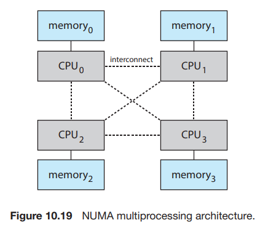

#### **The Memory Allocation Challenge in NUMA**

Standard memory allocation and page replacement algorithms treat all frames as equal. In NUMA, this is suboptimal.

- **Bad Allocation:** If a process running on **CPU0** gets a page fault, and the OS allocates a frame from **Memory3** (remote), every subsequent access to that page will suffer **remote access latency**, hurting performance.
- **Goal:** **Allocate memory "close" to the CPU that will use it.** "Close" means **minimum latency**, typically the memory bank on the same system board or NUMA node as the CPU.

#### **NUMA-Aware Operating System Strategies**

The OS must coordinate the **scheduler** and the **memory allocator**.

**1. CPU Affinity + Local Allocation:**

- **Scheduler:** Tries to keep a process/thread scheduled on the **same CPU (or NUMA node)** it ran on last. This is called **CPU affinity**.
- **Memory Allocator (Page Fault Handler):** When a page fault occurs, it allocates a frame from the **free-frame list of the NUMA node where the faulting process is currently running**.
- **Benefit:** Maximizes local accesses, improving cache hits and lowering memory latency.

**2. The Complexity of Multi-threaded Processes:** A single process with many threads can have its threads scheduled across **different NUMA nodes**. Where should its memory be allocated?

- **Problem:** If threads on Node 0 access memory allocated on Node 1, they suffer remote access penalties.

**OS Solutions to this Problem:**

- **Linux Approach:**
  1. **Scheduling Domains:** The kernel organizes CPUs into a hierarchy of **scheduling domains** representing the NUMA topology. The **Completely Fair Scheduler (CFS)** restricts thread migration to stay within a domain, preventing threads from wandering too far from their memory.
  2. **Per-Node Free Lists:** Linux maintains **separate free-frame lists for each NUMA node**. When a thread faults, it allocates from the list of the node it's running on.
- **Solaris Approach:**
  1. **Locality Groups (lgroups):** The kernel groups CPUs and memory into **lgroups** based on access latency. Each lgroup defines a set of resources with uniform, fast access.
  2. **Hierarchy:** Lgroups are arranged in a tree hierarchy based on increasing latency between them.
  3. **Allocation Policy:** The system tries to schedule **all threads of a process** and allocate **all memory for that process within a single lgroup**. If impossible, it uses the **nearest possible lgroups** to minimize cross-lgroup latency.

**Summary:** NUMA awareness requires the OS to:

1. **Understand the hardware topology** (which CPUs and memory are close).
2. **Make scheduling decisions** that keep threads near their memory.
3. **Make allocation decisions** that place pages in memory local to the accessing CPU. This coordination is crucial for achieving high performance on large-scale multiprocessor systems.

## **10.6 Thrashing**

#### **Definition and Root Cause**

**Thrashing** is a severe performance degradation where a process (or the entire system) spends more time **swapping pages** in and out of memory than doing useful work.

- **Root Cause:** A process does **not have "enough" frames** to hold its **current working set**—the set of pages it is actively and repeatedly using.
- **The Vicious Cycle:**
  1. The process needs a page not in memory → **Page Fault**.
  2. To free a frame, it must evict a page.
  3. But **every page in memory is currently in active use** (part of the working set).
  4. It evicts a page that will be needed again **almost immediately**.
  5. Shortly after, the process accesses that evicted page → **Another Page Fault**.
  6. The cycle repeats endlessly.
- **Result:** The process is trapped in a continuous storm of page faults. CPU utilization plummets because the process is constantly blocked waiting for disk I/O. The system spends its time **moving pages instead of running code**.

### **10.6.1 Cause of Thrashing**

#### **The Classic Thrashing Scenario**

This describes a **positive feedback loop of system collapse** that can happen with global page replacement and naive multiprogramming control.

**Step-by-Step Breakdown of the Disaster:**

1. **Initial State:** The OS monitors **CPU utilization**. If it's low, the OS assumes the CPU is idle and **increases the degree of multiprogramming** by adding a new process.
2. **Process Enters a New Phase:** An existing process starts a new phase (e.g., a new loop, a new function) and needs **more frames** for its new working set.
3. **Fault and Steal:** It begins page-faulting. Using a **global page-replacement algorithm**, it **takes frames from other processes**.
4. **Victim Processes React:** Those other processes now need their stolen pages back. They also start page-faulting, taking frames from yet other processes.
5. **Disk Queue Backup:** All these faulting processes generate I/O requests for the **paging device (disk)**. A long **I/O queue** forms.
6. **CPU Idles:** Processes block waiting for their page-in I/O. The **ready queue empties**. **CPU utilization drops**.
7. **OS Misdiagnosis:** The OS scheduler, seeing the low CPU utilization, thinks the system is underloaded. It **increases the degree of multiprogramming further**, adding yet another process.
8. **New Process Aggravates:** The new process also needs frames, causing **more page faults** and a **longer disk queue**.
9. **Complete Thrashing:** CPU utilization **plummets even more**. The system is now **thrashing**: processes are **constantly in the disk I/O queue**, and almost no productive work is done. Throughput collapses.

#### **The CPU Utilization Curve (Go to Figure 10.20)**

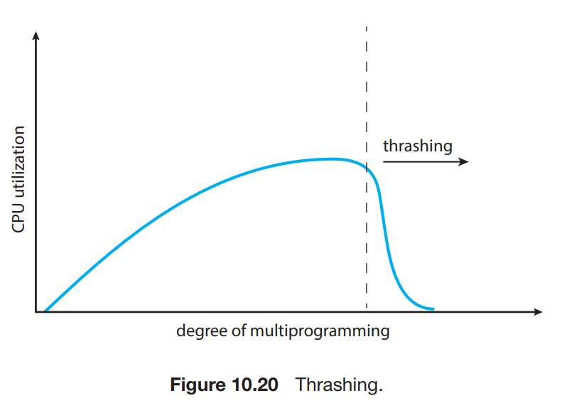

This classic graph shows the relationship:

- **X-axis:** Degree of multiprogramming (number of processes).
- **Y-axis:** CPU utilization.
- **The Curve:**
  - Initially, as you add processes, CPU utilization **increases** because it keeps the CPU busy when one process is blocked.
  - It reaches an **optimal point (peak)**.
  - **Beyond this point**, adding more processes causes **memory over-commitment**. The total working set of all processes exceeds physical memory.
  - **Thrashing begins.** CPU utilization **drops sharply** because the CPU is idle waiting for I/O.
- **Solution:** To recover, you must **decrease the degree of multiprogramming** (remove processes).

#### **Can Local Replacement Help?**

Using a **local replacement algorithm** can **limit the spread** of thrashing.

- **How:** If a process begins thrashing, it can only **evict its own pages**, not steal from others. This contains the damage to that single process.
- **Limitation:** It doesn't *solve* thrashing. The thrashing process still hogs the **paging device**, causing long I/O queues. This increases the **average page-fault service time for *every* process**, slowing down the entire system.

#### **The Fundamental Solution: Provide Enough Frames**

To prevent thrashing, a process must be given enough frames to hold its **current working set**. But how do we know what that is?

#### **The Locality Model**

This is a crucial concept for understanding program behavior and memory needs.

- **Definition:** A **locality** is a set of pages that are **actively used together** during a phase of execution. It could be a loop body, a function and its local variables, or a data structure being processed.
- **Program Execution:** A process executes by moving **from one locality to another** over time (see **Figure 10.21**). Localities can overlap (share some pages).
- **Basis for Caching:** The entire principle of caches (CPU cache, TLB, page cache) relies on this **locality of reference**. If memory access were perfectly random, caching would be useless.

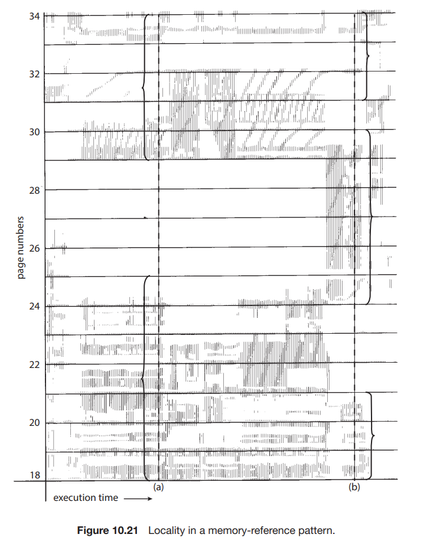

#### **The Working-Set Principle**

The **working set** is the set of pages in the **current locality**.

- **Key Insight:** If we allocate **enough frames to hold a process's entire current working set**, the process will **run without page faults** *within that locality*.
- It will only fault when it **transitions to a new locality** and needs to load a new set of pages.
- **If we allocate fewer frames than the working set size:** The process **cannot keep all actively used pages in memory**. It will **continuously fault** on pages it just evicted—this is the definition of **thrashing within a locality**.

**Figure 10.22** illustrates this with a page reference trace over time windows (`Δ`). The working set `WS(t1)` is {1,2,5,6,7} and later changes to `WS(t2)` = {3,4}. A process needs at least 5 frames during `t1` and 2 frames during `t2` to avoid thrashing.

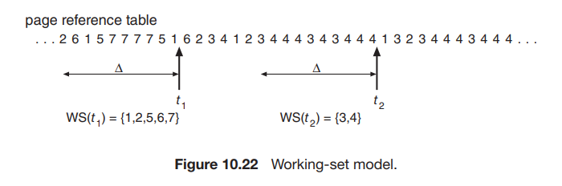

**Conclusion:** The OS must **estimate the working set size** for each process and allocate at least that many frames. This is the core idea behind the **working-set model**, which we'll explore next as a strategy for dynamic memory allocation to prevent thrashing.

### **10.6.2 Working-Set Model**

#### **Defining the Working Set**

The working-set model is a practical strategy to **estimate a process's current locality** and allocate memory accordingly to **prevent thrashing**.

- **The Window (Δ):** We define a **working-set window** of size **Δ**. This represents the most recent **Δ page references** (or a time interval of length Δ).
- **Working Set (WS):** The **set of distinct pages** referenced during that most recent window is the **working set**.
- **Dynamic Nature:** A page enters the working set when it's referenced. It **drops out** of the working set **Δ time units after its *last* reference** within the window (it "ages out").
- **Example (Follow Figure 10.22):** With Δ = 10 references:
  - At time **t1**, the last 10 references include pages {1, 2, 5, 6, 7}. So **WS(t1) = {1, 2, 5, 6, 7}**.
  - At time **t2**, the window has slid forward. The recent references are now {3, 4, ...}. So **WS(t2) = {3, 4}**.

#### **Choosing Δ: A Trade-off**

The accuracy of the working set as a locality measure depends heavily on Δ.

- **Δ too small:** The window may not capture the **entire locality**, missing some actively used pages. The working-set size is underestimated.
- **Δ too large:** The window may **span multiple localities**, including pages from an old, no-longer-active locality. The working-set size is overestimated.
- **Extreme Case (Δ = ∞):** The working set becomes **all pages ever touched** by the process, which is useless for dynamic allocation.

#### **The Core Principle: Demand vs. Supply**

The most critical output of the model is the **Working-Set Size (WSS_i)** for each process `i`.

- **Total Demand:** `D = Σ WSS_i` (sum of all working-set sizes).
- **Total Supply:** `m` = number of available physical frames.
- **Thrashing Condition:** If **D > m** (total demand exceeds supply), then **thrashing is inevitable**. At least one process will not have enough frames for its working set.
- **Stable Condition:** If **D ≤ m**, it is theoretically possible to give each process its full working set, eliminating thrashing.

#### **Using the Model for Allocation and Load Control**

The working-set model provides a policy for **dynamic memory allocation** and **controlling the degree of multiprogramming**:

1. **Monitor:** The OS continuously estimates the `WSS_i` for each active process.
2. **Allocate:** Give each process **at least `WSS_i` frames**.
3. **Admit New Processes:** If **extra frames** remain after satisfying all current `WSS_i`, the OS can **start a new process**.
4. **Suspend Processes:** If the total demand `D` **exceeds `m`**, the OS must **select a process to suspend** (swap out entirely). The freed frames are redistributed. The suspended process can be restarted later when memory is available.
- **Result:** This strategy **prevents thrashing** by ensuring allocations match actual needs, while **maximizing CPU utilization** by keeping multiprogramming as high as possible without overcommitting memory.

#### **The Implementation Challenge: Tracking the Working Set**

The major difficulty is **efficiently maintaining the moving window**. We need to know, for each page, whether it was referenced in the last Δ accesses.

**Approximation with Timer Interrupts and Reference Bits:** A practical, approximate method uses the **reference bit** and periodic interrupts:

- **Setup:** Let Δ = 10,000 references. Set a timer to interrupt **every 5,000 references**.
- **Operation at each interrupt:** For every page, **copy** the current hardware reference bit into a **history slot** in software, then **clear** the hardware bit.
- **Result:** We maintain, say, **2 history bits** representing the last two intervals (the last 10,000 references).
- **Determining WS Membership:** When considering a page:
  - If **any** of its history bits or its current reference bit is **1**, it was referenced in the last ~10,000-15,000 references → **It is (likely) in the working set**.
  - If **all bits are 0**, it hasn't been used recently → **Not in the working set**.
- **Trade-off:** This is **inexact** because we don't know the *exact* order within the 5,000-reference interval. We can improve accuracy by using **more history bits** and **shorter intervals**, but this increases **interrupt overhead** and memory for storing bits.

**Conclusion:** The working-set model provides a **sound theoretical framework** for thrashing prevention. While exact implementation is costly, its principles guide practical OS heuristics (like the **Page-Fault Frequency** scheme that follows) and explain why systems must monitor memory pressure and adjust process load dynamically.

### **10.6.3 Page-Fault Frequency (PFF)**

#### **A Simpler, Direct Approach**

The working-set model is theoretically sound but complex to implement precisely. The **Page-Fault Frequency (PFF)** strategy offers a more direct and measurable control mechanism.

**Core Insight:** Thrashing is directly observable as a **very high page-fault rate**. Therefore, we can **control thrashing by controlling the page-fault rate**.

#### **The PFF Algorithm**

The idea is to maintain the page-fault rate for each process within a **desired range**.

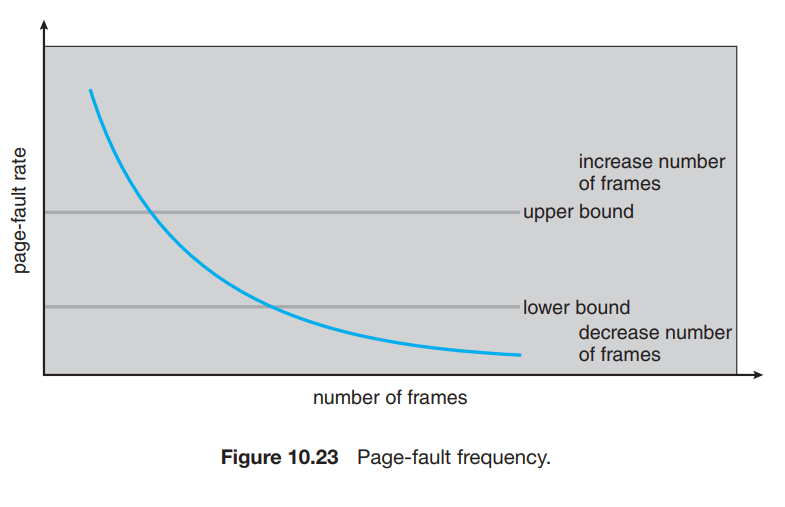

1. **Establish Bounds (See Figure 10.23):**
   - **Upper Bound:** If the page-fault rate **exceeds this limit**, the process is **faulting too often** → it needs **more frames**.
   - **Lower Bound:** If the page-fault rate **falls below this limit**, the process is **faulting very rarely** → it may have **too many frames** (we can take some away for other processes).
2. **Adjustment Rules:**
   - **Fault Rate > Upper Bound:** **Allocate an additional frame** to the process (if available).
   - **Fault Rate < Lower Bound:** **Remove a frame** from the process (add it to the free pool).
3. **Global Frame Management & Swapping:**
   - If a process needs a frame (fault rate too high) but **no free frames exist**, the OS must **select a victim process to swap out entirely**. The freed frames are then given to processes with critically high fault rates.
   - This provides a direct mechanism to **reduce the degree of multiprogramming** when memory is over-committed.

#### **Advantages over Working-Set Model**

- **Easier to Measure:** The page-fault rate is a straightforward, cheap metric to track (just count interrupts).
- **Direct Control:** It directly attacks the symptom of thrashing (high fault rate) by adjusting the cause (frame allocation).

**Both PFF and the working-set model aim for the same goal: dynamically adjusting frame allocation to match each process's actual needs, thereby preventing thrashing while maximizing multiprogramming.**

### **10.6.4 Current Practice**

#### **The Modern Solution: Ample Physical Memory**

While the algorithms (Working-Set, PFF) are important for OS design, the **prevailing real-world strategy** to avoid thrashing is much more straightforward:

- **Provide Enough RAM:** The best practice across all systems—from smartphones to servers—is to **install sufficient physical memory** so that the **combined working sets of all active applications and the OS can reside in RAM concurrently**.
- **Why this works:** With enough memory, page faults become rare events that occur mainly at process startup (loading code) or during major phase changes, not from constant contention. **Swapping to disk is largely avoided.**
- **User Experience:** This ensures smooth, predictable performance. Thrashing and swapping cause noticeable, unacceptable lag.

#### **The Reality Check**

- **Extreme Conditions:** Systems can still experience memory pressure (e.g., running too many massive applications, memory leaks), at which point the OS's **page-replacement and reclamation algorithms (Section 10.5.3)** become critical.
- **Mobile Systems:** They often use **memory compression** (Section 10.7) as a faster alternative to swapping, but the principle remains: try to keep active working sets in fast, uncompressed RAM.
- **Conclusion:** Sophisticated thrashing-avoidance algorithms are a **safety net**. The primary line of defense in modern system design is **adequate physical memory provisioning**. The algorithms ensure graceful degradation when that primary defense is overwhelmed.

## **10.7 Memory Compression**

#### **Concept: Compress, Don't Swap**

Memory compression is a **modern alternative to paging out to disk**. Instead of writing entire pages to slow secondary storage (swap), the OS **compresses multiple in-memory pages into a single frame**, freeing up frames for immediate use.

**Goal:** Reduce memory usage **without incurring slow disk I/O**.

#### **How It Works (Step-by-Step with Figures)**

**Scenario:** The free-frame list is low, triggering page reclamation.

1. **Select Victims (Figure 10.24):** The page-replacement algorithm (e.g., LRU clock) selects victim frames to free (e.g., frames 15, 3, 35, 26). They are placed on a **modified-frame list**.
2. **Traditional Path (Swapping):** These frames would be **written to swap space** on disk, then added to the free list. This is slow.
3. **Compression Path (Figure 10.25):**
   - Take one frame (**frame 7**) from the **free-frame list** to use as a **compression target**.
   - **Compress** the contents of several victim frames (e.g., 3 frames: 15, 3, 35) into this single frame (7).
   - Place this now-packed frame (7) into a new **compressed-frame list** (a holding area for compressed data).
   - The **original victim frames (15, 3, 35)** are now **empty** and can be added directly to the **free-frame list**.
   - **(Optional)** If the fourth victim frame (26) is not compressed, it might be handled separately (maybe swapped if dirty, or just freed if clean).
4. **Result:** We freed **3 frames** for immediate reuse, at the cost of **1 frame** used for storage, for a **net gain of 2 frames**. The compressed data stays **in RAM**.
5. **Accessing a Compressed Page:** If a process later accesses a page that's now compressed (e.g., page in frame 15), a **page fault occurs**. The OS **decompresses** the data from the compression frame (7) back into a regular free frame, updates the page table, and resumes execution.

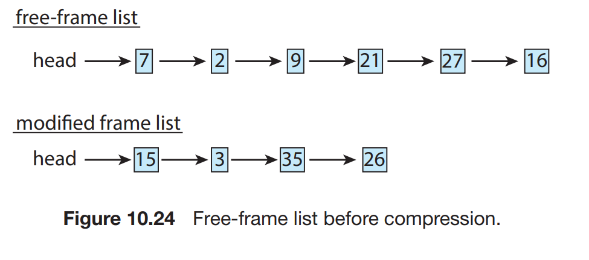

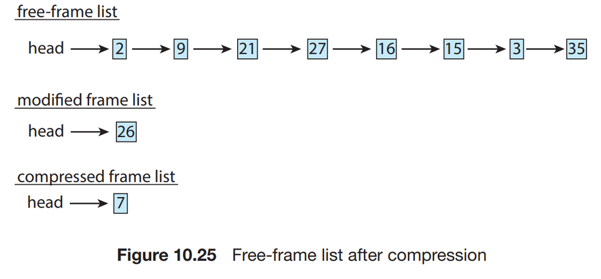

#### **Advantages Over Swapping**

- **Speed:** Compression/decompression using the CPU is **orders of magnitude faster** than disk I/O (even SSD). This makes **page-in latency much lower**.
- **Wear Reduction:** On mobile devices with flash storage, avoids frequent writes that wear out the storage.
- **Effectiveness:** Good compression algorithms can reduce pages to **30-50%** of their original size. Compressing 3 pages into 1 frame saves 2 frames, a significant gain.

#### **Widespread Adoption**

- **Mobile OS (Android, iOS):** Integral to memory management, as they typically **avoid traditional swap**.
- **Desktop OS:**
  - **macOS (since 10.9):** Uses compression **first** when memory is low, falling back to paging only if compression is insufficient.
  - **Windows 10:** Uses compression, especially for **Universal Windows Platform (UWP)** apps, providing a common memory management strategy across desktops and mobile devices.
- **Performance:** Benchmarks show compression outperforms paging **even to SSDs** in terms of latency.

#### **Design Trade-offs and Algorithms**

- **Compression Ratio vs. Speed:** The core trade-off.
  - **High Ratio (more savings):** Requires slower, more complex algorithms.
  - **Fast Algorithm:** May yield lower compression ratios.
- **Modern Solutions:** Use **fast, reasonably efficient algorithms** that leverage **multiple CPU cores for parallel compression**.
  - **Examples:** Microsoft's **Xpress**, Apple's **WKdm**. They are designed for speed, targeting ~30-50% compression.

#### **Key Considerations**

- **CPU Overhead:** Compression consumes CPU cycles. This is traded for **avoided I/O wait**.
- **Memory Overhead:** You must **allocate a frame to hold the compressed data**. The net gain is the freed frames minus this overhead frame.
- **When to Use:** Typically triggered **before swapping**, as a first line of defense against memory pressure. It's a **lighter-weight form of "swapping within RAM."**

## **10.8 Allocating Kernel Memory**

#### **Why Kernel Memory Allocation is Different**

When a **user process** requests memory (via `malloc()` or similar), the kernel satisfies it with **whole page frames** from the **global free-frame list**. This leads to **internal fragmentation** (e.g., a 1-byte request gets a 4KB page). For user processes, this is acceptable due to the simplicity of paging.

The **kernel**, however, has **different requirements** and manages its own memory from a **separate pool**. Two main reasons:

1. **Small, Variable-Sized Requests:** The kernel needs memory for data structures (task structs, inodes, network buffers) that are often **smaller than a page** (e.g., 256 bytes, 512 bytes). Using whole pages for each would cause **severe internal fragmentation**, wasting precious kernel memory. The kernel must be **extremely memory-efficient**.
2. **Physically Contiguous Memory Requirement:** Some hardware devices (DMA controllers, network cards, specialized hardware) perform **Direct Memory Access (DMA)**. They read/write directly to **physical RAM addresses**, bypassing the MMU and virtual memory. These devices often require **blocks of memory that are contiguous in *physical* address space**. User-mode allocations are **virtually contiguous but physically scattered**; kernel allocations for hardware must guarantee physical contiguity.

We examine two specialized allocators for kernel memory: the **Buddy System** and **Slab Allocation**.

### **10.8.1 Buddy System**

#### **Purpose and Mechanism**

The Buddy System manages a **large pool of physically contiguous memory** (e.g., a chunk of several megabytes). It is a **power-of-2 allocator** designed to **satisfy requests for physically contiguous memory** of various sizes while allowing efficient **coalescing** of freed blocks.

- **Unit of Allocation:** Memory is allocated in **blocks sized as a power of 2** (e.g., 4KB, 8KB, 16KB, ... up to the size of the entire pool).
- **Rounding Up:** If a kernel request is for a size *not* a power of 2, it is **rounded up to the next higher power of 2**. (e.g., a 21KB request becomes 32KB).
- **Initial State:** The entire pool is a single, large free block (say, 256KB).

#### **Example Allocation (Follow Figure 10.26)**

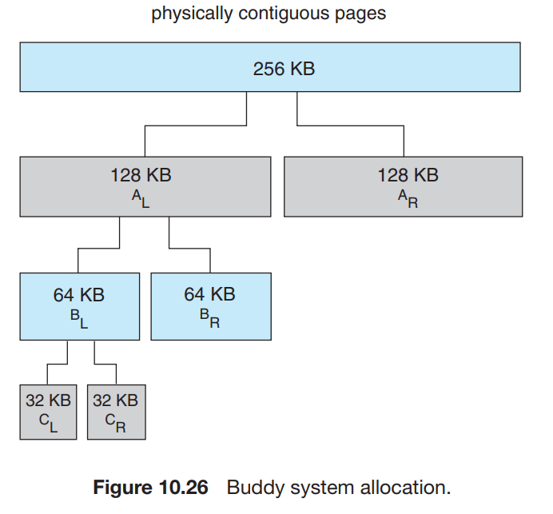

**Request:** 21 KB from a 256 KB pool.

1. The 256 KB block is **split into two 128 KB "buddies"** (`AL` and `AR`).
2. One 128 KB buddy (`AL`) is split into two **64 KB buddies** (`BL` and `BR`).
3. Since 21 KB rounds up to 32 KB (next power of 2), one 64 KB buddy (`BL`) is split into two **32 KB buddies** (`CL` and `CR`).
4. One of the 32 KB buddies (`CL`) is **allocated to satisfy the request**.
- **Result:** 32 KB is given for a 21 KB request → **11 KB internal fragmentation** within the allocated block.

#### **Key Advantage: Fast Coalescing**

When a block is freed, the allocator checks if its **"buddy"** (the block it was split from) is also free.

- If the buddy **is free**, the two are **merged (coalesced)** back into a single, larger free block of twice the size.
- This merging can recurse up the tree, eventually reconstructing large contiguous segments.
- **Example:** When `CL` (32KB) is freed, its buddy `CR` is checked. If `CR` is free, they merge into `BL` (64KB). Later, if `BL`'s buddy `BR` is free, they merge into `AL` (128KB), and so on.

#### **Major Drawback: Internal Fragmentation**

Because of **rounding up to powers of 2**, **up to nearly 50% of an allocated block can be wasted**.

- Worst case: A request for `(2^n) + 1` bytes gets rounded to `2^(n+1)` bytes, wasting almost half.
- Example: A 33 KB request requires a 64 KB block → **31 KB wasted (48% waste)**.

The Buddy System is therefore good for **coarse-grained, physically contiguous allocation**, but bad for small, precise allocations. This leads to the need for a more efficient allocator for kernel objects: **Slab Allocation**.

### **10.8.2 Slab Allocation**

#### **Concept: Dedicated Caches for Kernel Objects**

Slab allocation is designed for **efficient, zero-fragmentation allocation of small, fixed-size kernel data structures** (objects). It operates on the principle of **object caching**.

**Key Terms:**

- **Object:** An instance of a specific kernel data structure (e.g., a `task_struct`, an `inode`, a `semaphore`).
- **Slab:** One or more **physically contiguous pages** that are divided into **chunks**, each chunk sized to hold exactly one object.
- **Cache:** A collection of one or more slabs, all dedicated to storing **objects of the same type and size**. There is **one cache per unique kernel data structure**.

**Visual (Go to Figure 10.27):** The figure shows separate caches for 3KB objects and 7KB objects. Each cache contains slabs made from contiguous pages, which are partitioned into slots for objects.

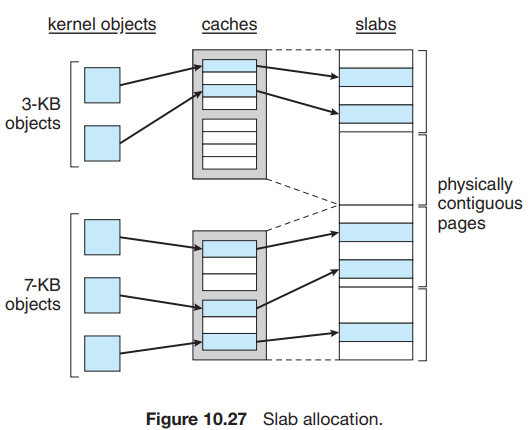

#### **How It Works**

1. **Cache Creation:** When the kernel initializes, it creates a **cache** for each type of frequently used object (e.g., `task_struct` cache, `inode` cache). Each cache is initially populated with one or more **slabs** containing a number of **free objects**.
2. **Allocation:** When the kernel needs a new object (e.g., to create a new process), it goes to the corresponding cache.
   - It first tries to get a **free object from a *partial* slab** (a slab with some free, some used objects).
   - If no partial slab exists, it takes a free object from an **empty slab** (all objects free).
   - If no empty slab exists, it **allocates a new slab** from the **buddy system** (requesting contiguous pages), adds it to the cache, and uses an object from it.
3. **Object States (Linux Example):** A slab can be:
   - **Full:** All objects used.
   - **Empty:** All objects free.
   - **Partial:** Mix of used and free.
4. **Deallocation:** When the kernel is done with an object (e.g., a process terminates), it **returns the object to its cache**, marking it as **free**. The memory is **not released to the general system**; it stays in the cache for immediate reuse.

#### **Two Major Benefits**

1. **No Internal Fragmentation:** Each cache's slabs are divided into chunks that are the **exact size** of the object they store. An allocation request returns **precisely the needed memory**, with **zero waste per object**. This solves the Buddy System's biggest flaw for small allocations.
2. **Fast Allocation/Deallocation:** Objects are **pre-allocated** and sitting in the cache.
   - **Allocation** is just marking a free object as used.
   - **Deallocation** is just marking it free again.
   - This avoids the overhead of calling the general-purpose allocator (buddy system) for every small request. It's especially efficient for **high-frequency allocation/deallocation patterns** common in the kernel.

#### **Historical Context and Linux Variants**

- **Origin:** First appeared in **Solaris 2.4**.
- **Linux Adoption:** Originally used the Buddy System. Since **kernel 2.2**, adopted a slab allocator called **SLAB**.
- **Modern Linux Evolution:** Linux now has three slab-like allocators:
  1. **SLAB:** The original, full-featured implementation. Maintains per-CPU queues for objects to reduce lock contention, but has significant metadata overhead.
  2. **SLOB (Simple List Of Blocks):** Designed for **embedded systems with very limited memory**.
     - Maintains **three simple linked lists**: `small` (<256B), `medium` (<1024B), `large` (< page size).
     - Uses a **first-fit** policy on the appropriate list.
     - Minimal overhead, but less efficient for complex systems.
  3. **SLUB (the Unqueued Allocator):** Since **kernel 2.6.24**, the **default allocator**.
     - **Reduces metadata overhead** compared to SLAB. Stores management data in the kernel's standard **page structure**, not in separate slabs.
     - **Removes per-CPU queues**, freeing significant memory on large multi-processor systems.
     - Provides **better performance and scalability** on modern multi-core systems.
     - Retains the core slab benefits (object caching, no fragmentation).

**In summary:** The Buddy System provides **physically contiguous memory in coarse chunks**. The Slab Allocator (and its variants) builds on top of it to provide **fast, zero-fragmentation allocation of fixed-size objects** for the kernel's internal data structures. They are complementary components of the kernel's memory management.

## **10.9 Other Considerations**

### **10.9.1 Prepaging**

##### **The Problem with Pure Demand Paging: Cold Start Penalty**

In a pure demand-paging system, a process (or a resumed process) starts with **zero pages in memory**. Every page in its initial working set must be faulted in one by one, causing a **burst of page faults** at startup, leading to noticeable lag.

**Prepaging** is a proactive strategy to **reduce these initial faults** by loading pages **before they are actually referenced** (on speculation).

##### **How Prepaging Can Work**

- **Working-Set Based:** When a suspended process is about to be resumed, the OS could **preload its entire remembered working set** (the set of pages it was actively using before suspension) back into memory *before* restarting its execution.
- **File-Based (Read-ahead):** For sequential file access, the OS can predict that after reading block N, the process will likely need block N+1. It can **prefetch** the next block(s) from disk into the page cache while the process is working on the current block. This is common in file systems (e.g., Linux's `readahead()` system call).

##### **The Critical Trade-off: Cost vs. Benefit**

Prepaging is **not free**. It consumes **I/O bandwidth and memory frames**.

- **Let:** `s` = number of pages prepaged.
- **Let:** `α` = fraction of prepaged pages that are **actually used** (0 ≤ α ≤ 1).
  - `s * α` pages are **useful prepages** (they prevent a future page fault).
  - `s * (1 - α)` pages are **wasted prepages** (loaded but never used).

**Prepaging is beneficial only if:** **(Cost of `s * α` saved page faults) > (Cost of prepaging `s * (1 - α)` unnecessary pages)**

- **If `α` is close to 1:** Most prepaged pages are used → **Big win.** The I/O cost of prepaging is less than the total cost of servicing many individual page faults later.
- **If `α` is close to 0:** Most prepaged pages are wasted → **Big loss.** You've incurred disk I/O and used up memory frames for nothing.

##### **Practical Challenges**

- **Predicting the Future:** It's hard to know *exactly* which pages a program will need next, especially for arbitrary code execution. Predictions are easier for **sequential file access**.
- **Overcommitting Memory:** Prepaging consumes frames that could be used for other processes. If predictions are wrong, it can actually *cause* paging in other processes.

**Conclusion:** Prepaging is a **high-risk, high-reward optimization**. It is most reliably applied in **predictable scenarios** like file read-ahead or restoring a known working set. For general program execution, modern systems rely more on **large physical memory** and **good caching** to mitigate the cold-start penalty, rather than aggressive speculative prepaging.

### **10.9.2 Page Size**

#### **The Fundamental Trade-offs**

Choosing a page size is a critical architectural decision with **no single optimal answer**. It involves balancing multiple, often conflicting, factors. Page sizes are typically **powers of 2**, ranging historically from 4KB to several megabytes.

Let's analyze the trade-offs:

##### **Arguments for a LARGER Page Size**

1. **Smaller Page Tables (Reduced Memory Overhead):**
   - For a fixed virtual address space size, **larger pages mean fewer total pages**.
   - Example: A 4MB (`2^22` bytes) virtual address space.
     - 1KB pages: 4,096 pages → large page table.
     - 8KB pages: 512 pages → much smaller page table.
   - Since **each process needs its own page table**, smaller page tables save significant kernel memory.
2. **Reduced Page Fault Overhead (Fewer Faults):**
   - Larger pages bring more data into memory per fault.
   - Example: A 200KB process that actively uses 100KB.
     - With a 200KB page: **1 page fault** loads everything (used + unused).
     - With 1KB pages: Up to **100 page faults** just for the used data.
   - Each page fault has high fixed software overhead (interrupt handling, table updates). Fewer faults reduce this overhead.
3. **Improved I/O Efficiency for Large Transfers:**
   - Disk I/O time = Seek Time + Rotational Latency + Transfer Time.
   - **Seek and Latency dominate** (~8 ms), Transfer time is minimal (~0.01 ms for 512 bytes).
   - Reading one **16KB page** takes only marginally longer than reading one **4KB page** (e.g., 8.02 ms vs. 8.01 ms), but transfers **4x more data per I/O operation**.
   - **Amortizes the high seek/latency cost over more data.**

##### **Arguments for a SMALLER Page Size**

1. **Less Internal Fragmentation (Better Memory Utilization):**
   - Memory is allocated in whole pages. A process rarely ends exactly on a page boundary.
   - **On average, half of the *last* page of each process is wasted**.
   - **Waste per process:** `Page Size / 2`.
     - 4KB page → ~2KB average waste.
     - 2MB page → ~1MB average waste! (Huge problem).
   - Smaller pages minimize this per-process waste.
2. **Better Resolution / Matches Locality (Reduces I/O *Volume*):**
   - Smaller pages allow the OS to bring in **only the data that is actually needed**, precisely matching the program's **locality**.
   - Example: A process only uses 100KB scattered across a 200KB address space.
     - With 4KB pages: Might need to load ~25 pages (100KB), leaving the other 25 pages on disk.
     - With 200KB page: **Forced to load all 200KB**, including 100KB of unused data. This wastes **I/O bandwidth and memory frames**.
   - Smaller pages reduce **unnecessary I/O** and allow more efficient use of physical RAM.
3. **Finer-Grained Protection and Sharing:**
   - Permissions (read, write, execute) are set at the **page level**.
   - Smaller pages allow more precise protection of memory regions (e.g., a small guard page between stacks).
   - Allows sharing of smaller regions between processes.

#### **The Historical Trend**

- **1980s-1990s:** The **4KB page** became a **de facto standard**, representing a compromise between the factors above.
- **Modern Systems:** Trend is toward **supporting multiple page sizes**.
  - **Why?** Different workloads benefit from different sizes.
  - **Large Pages (e.g., 2MB, 1GB):** Used for **big, contiguous data sets** (scientific computing, databases) to **reduce TLB misses and page fault counts**.
  - **Small Pages (4KB):** Remain the default for general-purpose code, minimizing fragmentation.
- **Mobile/Embedded:** Also use larger pages (e.g., 4KB, 16KB, 64KB) to reduce TLB pressure and management overhead, as physical memory is often constrained.

**Conclusion:** The choice is a **classic engineering compromise**. The modern solution is not to choose one, but to **support multiple page sizes** (via mechanisms like **huge pages** or **superpages**), allowing the OS and applications to select the appropriate granularity for different parts of the address space. The next section explores this.

### **10.9.3 TLB Reach**

#### **The Problem: TLB as a Performance Bottleneck**

The **Translation Lookaside Buffer (TLB)** is a small, fast hardware cache for page table entries. Its performance is critical because every memory access requires an address translation.

- **TLB Hit Ratio:** The percentage of translations found in the TLB. A low hit ratio means frequent, slow walks of the full page table in memory.
- **Limitation:** TLBs are **small** (often 64-1024 entries) due to cost and power constraints. If a process's **working set** (the set of pages it's actively using) doesn't fit in the TLB, performance plummets due to constant **TLB misses**.

#### **TLB Reach: A Key Metric**

- **Definition:** **TLB Reach = (Number of TLB Entries) × (Page Size)**
- **Interpretation:** The total amount of **physical memory that can be simultaneously mapped by the TLB** without a miss. It's the **"coverage"** of the TLB.
- **Goal:** The TLB reach should be **at least as large as the process's working set**. If not, the process will thrash the TLB just as it can thrash pages in memory.

#### **Strategies to Increase TLB Reach**

**1. Increase the Number of TLB Entries:**

- **Effect:** Directly increases reach (Reach ∝ Entries).
- **Drawback:** Hardware cost and power consumption increase significantly (TLB uses expensive associative memory).

**2. Increase the Page Size:**

- **Effect:** Dramatically increases reach (Reach ∝ Page Size). Doubling page size doubles reach with the *same* number of TLB entries.
- **Example:** 64-entry TLB with 4KB pages → Reach = 256KB. With 2MB pages → Reach = **128MB**.
- **Drawback:** Leads to increased **internal fragmentation** (as discussed in 10.9.2). Using a single, large page size is a blunt instrument.

**3. Support Multiple Page Sizes (The Modern Solution):** This is the most flexible approach. The OS and hardware collaborate to use **large pages ("huge pages")** for big, contiguous data regions, while keeping **small pages** for general code and data.

- **How it works:** The TLB entry includes a **field to specify the page size** it maps (e.g., 4KB, 2MB, 1GB). The OS can choose the appropriate size when setting up mappings.
- **Example - Linux Huge Pages:** The default is 4KB, but an application (like a database) can request a portion of its address space to be backed by 2MB or 1GB huge pages. One TLB entry then covers a massive region, eliminating thousands of potential TLB misses.

#### **Advanced Hardware Support: ARMv8 Contiguous Bit**

The ARMv8 architecture provides a clever optimization for increasing effective TLB reach without changing the *fundamental* page size used by the OS.

- **Contiguous Bit:** A special bit in a TLB entry.
- **When Set:** Indicates that this single TLB entry maps **not one, but a contiguous block of *adjacent* base-sized pages**.
- **Example Configurations from the text:**
  - A TLB entry can map **16 contiguous 4KB pages** → acts like a **64KB page**.
  - Or **32 contiguous 32MB blocks** → acts like a **1GB region**.
- **Benefit:** The OS can tell the hardware that a certain range of virtual addresses maps to a contiguous physical range. The hardware can then **use a single TLB entry for the entire block**, massively boosting effective reach. The OS still manages memory in the base page size (e.g., 4KB) for fine-grained control, but the TLB sees large blocks.

#### **Software-Managed TLBs and the Cost**

Some architectures (like MIPS, SPARC) have **software-managed TLBs**. On a TLB miss, a hardware trap occurs, and an **OS handler** must walk the page table and load the correct entry into the TLB.

- **Cost:** This is **slower** than a hardware page-table walker (like in x86).
- **Benefit for Multiple Sizes:** It gives the **OS maximum flexibility** in choosing page sizes and managing TLB contents, as the management policy is in software.
- **Trade-off:** The performance overhead of software management is often offset by the **dramatically higher TLB hit ratio** achieved through smart use of multiple page sizes and contiguity optimizations.

**Conclusion:** Increasing **TLB reach** is essential for performance in memory-intensive applications. The modern strategy is **not just bigger TLBs**, but **smarter use of larger and/or contiguous page mappings** through OS–hardware cooperation, allowing a small TLB to cover a very large working set effectively.

### **10.9.4 Inverted Page Tables**

#### **Recap: The Goal of Inverted Page Tables**

As introduced in Section 9.4.3, the standard per-process page table has one entry per *virtual page*, which becomes huge for large address spaces (e.g., 2^20 entries for 32-bit with 4KB pages).

- **Inverted Page Table (IPT) Goal:** Drastically reduce the memory overhead of translation tables. It does this by having **one entry per *physical frame***, not per virtual page.
- **Structure:** Each entry in the IPT contains: **<Process-ID (PID), Virtual Page Number (VPN)>**. It answers the question: "Which process, and which of its virtual pages, is currently occupying this physical frame?"

#### **The Problem with Demand Paging and Inverted Tables**

While the IPT efficiently tracks what's **in memory**, it **loses vital information** needed by demand paging:

- **Missing Information:** The IPT does **not** store the **location on disk** (backing store address) for pages that are *not currently in memory*. It only knows about pages that are *currently resident*.
- **Consequence:** When a **page fault occurs** for a non-resident page, the OS cannot use the IPT to find where on disk to fetch that page from.

#### **The Required Solution: External Page Tables (EPTs)**

To handle page faults, the system must maintain **additional, per-process data structures** alongside the IPT.

- **External Page Table (EPT):** One per process. It functions like a **traditional forward page table**, mapping each virtual page number to its **backing store location** (disk address). It may also contain other flags (valid, dirty, etc.).
- **Role:** The EPT is **only consulted during a page fault** to locate the missing page on disk. It is **not used for normal address translation** (that's the IPT's job).

#### **A Major Complication: Paging the Page Tables**

Since EPTs can be large (one per virtual page), they themselves are too big to keep permanently in kernel memory, especially with many processes.

- **Solution:** The OS **pages the EPTs** themselves. They are stored in virtual memory and can be swapped out.
- **The Nightmare Scenario (Double Page Fault):**
  1. Process A accesses virtual page X → **Page fault** (X not in IPT).
  2. OS page fault handler needs to consult **Process A's External Page Table (EPT)** to find X's disk location.
  3. **Oops!** The needed portion of Process A's EPT is itself **paged out to disk**.
  4. This triggers a **second page fault** to bring in the EPT page itself.
- **Result:** A single user-level page fault can lead to **two disk I/O operations**: one to fetch the EPT page, then another to fetch the actual user page. This causes significant delay and complexity.

#### **Kernel Handling and Impact**

- **Careful Kernel Design:** The OS must handle this **recursive fault** scenario very carefully to avoid infinite loops. Typically, the kernel pins (keeps resident) a minimal set of its own data structures, including **the page of the IPT and the EPT that describes the currently running fault handler**.
- **Performance Trade-off:** The **memory savings** of the inverted page table (a single, global table) come at the cost of **increased complexity** and the potential for **higher latency on page faults** due to the need to possibly fault in an EPT.
- **Use Case:** Inverted page tables are most beneficial in systems where **physical memory is very scarce and expensive** relative to address space size, and where the performance penalty of complex fault handling is acceptable (e.g., some embedded or high-end server systems). Modern 64-bit systems often use other schemes (like multi-level page tables) that are less complex for demand paging.

### **10.9.5 Program Structure**

#### **The Transparency Illusion and Programmer/Compiler Awareness**

While demand paging aims to be **transparent**, its performance impact is heavily influenced by **how a program accesses memory**. Programmers and compilers that understand paging can write **cache-friendly** and **page-friendly** code for significant speedups.

#### **A Classic Example: Array Traversal Order**

The example starkly shows how a simple logic change can cause **16,384 page faults vs. 128**.

**Assumptions:**

- Page size = 128 words (integers).
- Array `data[128][128]` is stored in **row-major order** (C/C++ default). This means `data[0][0]` to `data[0][127]` occupy contiguous memory, filling **Page 0**. `data[1][0]` to `data[1][127]` fill **Page 1**, and so on.
- The OS allocates **fewer than 128 frames** to the program (very likely).

**Code 1: Column-Major Inner Loop (DISASTER)**

```
for (j = 0; j < 128; j++)
    for (i = 0; i < 128; i++)
        data[i][j] = 0;  // BAD: Accesses column j across all rows
```

- **Access Pattern:** `data[0][0]` (Page 0), `data[1][0]` (Page 1), ..., `data[127][0]` (Page 127). This touches **a different page on every single access**.
- With <128 frames, after 127 iterations, all frames are full of different pages from column 0. The next access (`data[0][1]`) needs Page 0 again, but it was likely evicted. **Page fault**.
- **Result:** Every single array access (16,384 total) causes a **page fault** because the loop **strides across pages**, exceeding the available frames.

**Code 2: Row-Major Inner Loop (OPTIMAL)**

```
for (i = 0; i < 128; i++)
    for (j = 0; j < 128; j++)
        data[i][j] = 0;  // GOOD: Accesses all elements in row i (Page i)
```

- **Access Pattern:** All 128 elements of `data[0][j]` (Page 0), then all 128 elements of `data[1][j]` (Page 1), etc.
- **Page Faults:** Only **one fault per page** (128 total). Once Page 0 is loaded, all 128 accesses to it hit. Then it can be evicted for Page 1, and so on. Perfect **locality within each page**.

#### **General Principles for Good Locality**

1. **Data Structure Choice:**
   - **Good Locality:** **Stacks, sequential arrays** (accessed linearly). They concentrate references in few pages.
   - **Bad Locality:** **Hash tables, linked lists with scattered nodes**. They intentionally randomize or scatter accesses, causing many page touches.
   - **Trade-off:** You must balance locality against the data structure's primary purpose (e.g., fast lookup for hash tables).
2. **Compiler and Loader Optimizations:**
   - **Separate Code & Data:** Mark code pages as **read-only**. Clean pages never need to be written back to disk on eviction, saving I/O time.
   - **Reentrant Code:** Allows multiple processes to share the same physical code pages (e.g., shared libraries), reducing total memory footprint.
   - **Page Boundary Alignment:** The loader can try to place entire functions/routines within a **single page** to minimize intra-procedure page faults.
   - **Packing Related Code:** Functions that call each other frequently (**working set grouping**) can be packed into the same page to reduce TLB misses and faults during execution flow.
   - **The Bin-Packing Problem:** The loader faces the challenge of placing variable-sized code and data segments into fixed-size pages to **minimize cross-page references**. This is especially impactful with **large page sizes**, where poor packing wastes more space and causes more unnecessary page inclusions.

#### **Key Takeaway**

**Memory access pattern is performance.** Even with ample RAM, poor locality increases **cache misses (CPU cache)**, **TLB misses**, and potential **page faults**. Writing **spatially local** code—accessing memory addresses close together before moving far away—is a fundamental optimization that benefits all levels of the memory hierarchy, from L1 cache to virtual memory.

### **10.9.6 I/O Interlock and Page Locking**

#### **The Problem: I/O to a Page That Gets Evicted**

This addresses a critical **race condition** between **page replacement** and **Direct Memory Access (DMA) I/O**.

**The Dangerous Sequence:**

1. **Process A** issues a **read()** system call to read disk data into its memory buffer (a user-space address).
2. The OS sets up the **DMA transfer**: tells the disk controller the **physical address** of the buffer page and starts the I/O. Process A is then put to sleep waiting for I/O completion.
3. The CPU switches to **Process B**.
4. **Process B** causes page faults. Using a **global replacement algorithm**, it selects a victim frame. **Unfortunately, it picks the exact frame that contains Process A's I/O buffer**, which is currently in the middle of a DMA transfer. The OS pages it out.
5. The **disk controller finishes the DMA transfer**, writing data directly to the **original physical frame**. But that frame now holds a **completely different page** belonging to Process B (or someone else).
6. **Result:** **Data corruption.** Process A's buffer contains wrong data, and Process B's page is silently overwritten.

This is why **frames involved in pending I/O must be locked in memory (pinned)**.

#### **Solutions**

**1. Copying via System Buffers (No Direct I/O):**

- **Method:** Never allow DMA directly to/from user-space buffers. Instead:
  - For a **read**: Disk → **Kernel system buffer** (always resident) → copy to user buffer.
  - For a **write**: User buffer → copy to **Kernel system buffer** → Disk.
- **Advantage:** Eliminates the race condition; kernel buffers are pinned.
- **Disadvantage:** **Extra memory copy** on every I/O operation, causing significant CPU overhead and latency. Often unacceptable for high-performance I/O.

**2. Page Locking (Pinning) - The Common Solution:**

- **Mechanism:** Each frame has a **lock (or pin) bit**. If set, the frame **cannot be selected for replacement**.
- **Procedure for DMA I/O:**
  1. Before starting the DMA transfer to/from a user page, the OS **locks (pins)** the corresponding frame(s) in memory.
  2. The I/O proceeds directly to/from the user buffer.
  3. Upon I/O completion interrupt, the OS **unlocks** the frame(s).
- **This is depicted in Figure 10.28:** The buffer frame must be in memory and locked for the duration of the disk I/O.

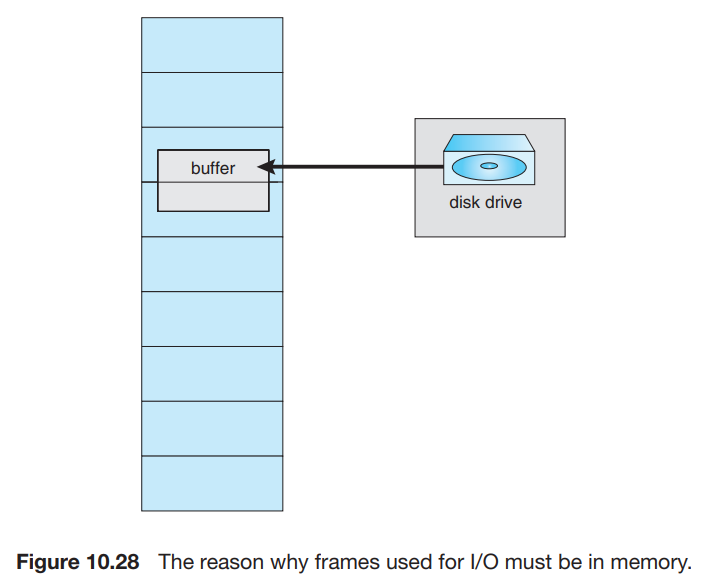

#### **Other Uses of Page Locking**

1. **Kernel Code and Critical Data:** The core kernel, and especially the **memory management code itself**, is often **locked in memory** to prevent a page fault within the page fault handler (which would cause a deadly recursive fault).
2. **Real-Time and Database Applications:** Applications (e.g., databases) that manage their own disk caching may **pin their buffer pool** in memory to guarantee performance and control, bypassing the OS page cache. This requires **special privileges**.
3. **Preventing Immediate Re-Eviction (The "Second-Chance" for New Pages):**
   - **Scenario:** A low-priority process faults, a page is brought in for it. Before it gets CPU time to use it, a high-priority process faults and wants a frame. The freshly loaded (but unused) page from the low-priority process looks like a perfect clean victim.
   - **Policy Decision:** Should we allow this? It wastes the I/O done for the low-priority process.
   - **Solution using Lock Bit:** When a page is faulted in, **lock it temporarily**. The lock is released only **after the faulting process has been scheduled and had a chance to use the page at least once**. This gives the page a "fair chance" to be useful.

#### **Dangers and Safeguards**

- **Lock Bit Leak:** If a bug causes a lock bit to be set but never cleared, that frame becomes **permanently unusable**, effectively reducing available memory. This is a serious kernel bug.
- **Resource Exhaustion:** A malicious or buggy process could lock all of memory.
- **OS Safeguards:** Modern OSes impose limits and can **override lock hints** under extreme memory pressure.
  - **Example - Solaris:** Allows locking hints but is free to **disregard them** if the free-frame pool becomes too small or if a process requests excessive locking.

## **10.10 Operating-System Examples**

### **10.10.1 Linux**

Linux uses a combination of **demand paging** and a **global page-replacement policy** that approximates LRU using a **two-list (active/inactive) clock-like algorithm**.

#### **Core Data Structures: Active and Inactive Lists**

To manage page aging and reclamation, Linux maintains two primary page lists:

1. **Active List:** Contains pages that are **currently considered "in use" or "hot"** (part of a process's working set).
2. **Inactive List:** Contains pages that are **candidates for reclamation** (considered "cold" or not recently used). These pages are eligible to be freed if memory is needed.

#### **The Page Lifecycle Algorithm (Follow Figure 10.29)**

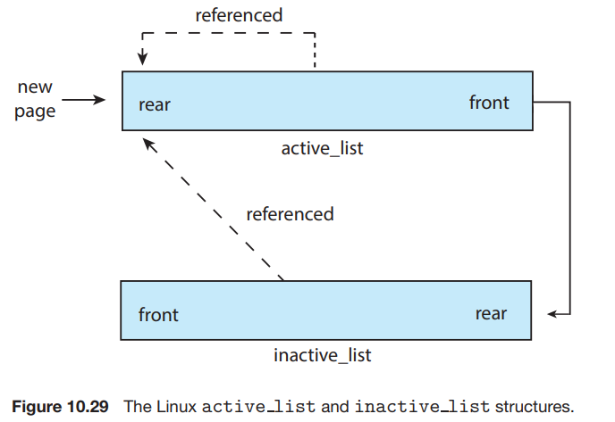

This is a refined **clock algorithm** with two hands (lists).

- **Initial Allocation & Reference:**
  - When a page is first allocated (on a page fault), its **accessed (reference) bit is set**, and it is placed at the **rear (tail)** of the **Active List**. It is considered "new and hot".
- **Active List Management:**
  - While on the Active List, if the page is **referenced again**, its accessed bit is set and it is **moved to the rear** of the Active List (promoted, kept hot).
  - Periodically, a kernel daemon (**`kswapd`**) **scans the Active List and clears the accessed bits** of pages as it passes. This is the "clock hand" movement.
  - A page that **survives a scan without its accessed bit being set again** slowly moves towards the **front** of the Active List as newer pages are added to the rear. It becomes a candidate for demotion.
- **Demotion to Inactive List:**
  - To keep the lists balanced, when the Active List grows too large, pages from the **front** of the Active List (the oldest, least recently accessed) are moved to the **rear of the Inactive List**.
  - Once in the Inactive List, a page is **in the "danger zone"** but can still be rescued.
- **Rescue from Inactive List:**
  - If a page in the **Inactive List is referenced** (accessed bit set), it is **promoted back to the rear of the Active List**.
  - This prevents frequently used pages from being evicted even if they briefly looked cold.
- **Reclamation from Inactive List:**
  - When the **page-out daemon (`kswapd`)** runs, it primarily scans the **Inactive List** for victims.
  - It checks the **accessed bit** and **dirty (modified) bit** of pages in the Inactive List:
    - If **accessed bit = 1**: Page was recently used → **promote back to Active List**.
    - If **accessed bit = 0**: Page is truly cold.
      - If **clean (not dirty)**: Can be **immediately reclaimed** (added to free list).
      - If **dirty**: Must be scheduled for **write-back to disk** before its frame can be freed.

#### **The Role of `kswapd` (Page-Out Daemon)**

- **Trigger:** `kswapd` periodically wakes up or is triggered when **free memory falls below a threshold** (similar to the reaper in Section 10.5.3).
- **Action:** It performs the **scanning and reclamation process** described above, moving pages between lists and freeing frames, aiming to keep **free memory above a high-water mark**.
- **Global Replacement:** Since `kswapd` operates on a global set of pages (from all processes), Linux uses a **global replacement policy**. This allows memory to flow dynamically to the processes that need it most.

**This two-list strategy is a sophisticated LRU approximation.** The Inactive List acts as a **"grace period" or probationary zone** before final eviction, allowing recently used pages a chance to prove they are still active, thereby improving accuracy over a simple single-clock algorithm.

### **10.10.2 Windows**

#### **Architectural Support**

Windows 10 is a hybrid OS supporting multiple architectures with vast address spaces:

- **32-bit (x86):** 2-3 GB virtual address space per process, up to **4 GB physical RAM**.
- **64-bit (x86-64, ARM):** **128 TB** virtual address space, supports up to **24 TB** physical RAM (Windows Server supports up to 128 TB).
- **Features Supported:** Demand paging, copy-on-write, shared libraries, memory compression, and clustering.

#### **Key Feature: Paging with Clustering**

Windows uses an **aggressive form of prepaging** to exploit **spatial locality**.

- **Clustering:** On a page fault, Windows doesn't just load the faulting page. It loads a **cluster (block) of pages** surrounding the faulting page.
- **Cluster Sizes:**
  - **Data Page Fault:** Cluster of **3 pages** (the faulting page + the page before and after it).
  - **Other Page Faults (e.g., code):** Cluster of **7 pages**.
- **Rationale:** Anticipates that the process will likely need nearby pages soon. This **amortizes the disk I/O cost** (seek/latency) over multiple pages, reducing future page faults.

#### **Working-Set Management**

Windows actively manages each process's **working set** (its resident pages in memory) using soft limits.

- **Default Limits (for a new process):**
  - **Working-Set Minimum:** 50 pages (guaranteed lower bound if memory is available).
  - **Working-Set Maximum:** 345 pages (soft upper limit).
- **Flexible Enforcement:** These are **guidelines, not hard limits**.
  - A process can **grow beyond its maximum** if free memory is plentiful.
  - A process can **shrink below its minimum** under severe memory pressure.

#### **Page Replacement Policy: Hybrid Approach**

Windows uses a combination of **local** and **global** replacement, built around the **clock algorithm (LRU approximation)**.

- **Local Policy (Per-Process):** When a process at its working-set maximum incurs a page fault **and free memory is low**, the virtual memory manager uses a **local clock algorithm** to select a victim page **from that process's own working set**.
- **Free List:** The system maintains a **list of free page frames**. If free memory is above a threshold, page faults are satisfied from this list.

#### **Global Memory Pressure Response: Automatic Working-Set Trimming**

When **system-wide free memory falls below a critical threshold**, Windows activates **global reclamation**.

- **Mechanism:** The **virtual memory manager** systematically **reduces the size of process working sets** to free frames.
- **Target Selection:** It evaluates all processes. Priority for trimming is given to:
  1. **Larger processes** (more pages to take).
  2. **Idle processes** (less likely to need their pages immediately).
- **Trimming Rules:**
  - A process is trimmed **down towards its working-set minimum**.
  - If severe pressure continues, trimming can **force a process below its minimum**.
  - **Both user and system processes** are subject to trimming (though critical kernel pages are locked).
- **Goal:** Quickly replenish the **global free-frame list** to a safe level.

**Summary:** Windows memory management is **adaptive and hybrid**. It uses **local replacement for contained pressure** within a process, and **aggressive global trimming for system-wide memory crises**. The **working-set model with soft limits** provides a framework, while **clustering** optimizes for common access patterns. This balances performance for individual applications with overall system stability.

### **10.10.3 Solaris**

#### **Core Mechanism: The Two-Handed Clock (`pageout`)**

Solaris uses a sophisticated global page-replacement algorithm known as the **two-handed clock**, a variant of the second-chance algorithm. The goal is to maintain a sufficient pool of free pages.

- **Key Parameter: `lotsfree`** = Threshold to begin active page scanning. Typically set to **1/64th of total physical memory**.
- **Trigger:** Four times per second, the kernel checks free memory. If **free pages < `lotsfree`**, the **`pageout` daemon** (page scanner) is activated.

#### **The Two-Handed Clock Operation**

Imagine a clock face with **two hands** moving in the same direction, with a fixed gap (`handspread`) between them.

1. **Front Hand (Clearing Hand):**
   - Scans through all pages in memory.
   - For each page, it **clears (sets to 0) the reference bit**. This action **marks the page as "possibly cold"** starting now.
2. **Back Hand (Reaping Hand):**
   - Follows the front hand at a fixed distance (`handspread` pages behind).
   - Checks the **reference bit** of the page the front hand cleared earlier.
   - **Decision:**
     - If **reference bit = 0**: The page was **not re-referenced** in the interval between the two hands passing. It is **truly cold**. The back hand **reclaims** it: if dirty, schedules a write-back; then adds its frame to the free list.
     - If **reference bit = 1**: The page **was referenced again** after the front hand cleared it. It is **still hot**. The back hand **skips it** (gives it a second chance). Its bit remains 1 until the front hand comes around again.

**Advantage over Single-Hand Clock:** The two-handed clock introduces a **measurable "aging" period** (`handspread` / `scanrate`). A page must survive **unreferenced** for this entire period before being evicted, making LRU approximation more accurate.

#### **Dynamic Scan Rate (`scanrate`)**

The speed at which the clock hands move is not fixed. It adjusts dynamically based on memory pressure.

- **`slowscan`:** Default = **100 pages/second**. Used when memory pressure is just beginning (free memory just below `lotsfree`).
- **`fastscan`:** Maximum = **min(8192, total_physical_pages / 2) pages/second**. Used under severe memory pressure.
- **Adaptation:** As free memory decreases, the `scanrate` **increases linearly** from `slowscan` to `fastscan` (see **Figure 10.30**). This makes reclamation more aggressive when needed.

**Aging Interval:** The time between a page's reference bit being cleared and checked is:  
**Aging Time = `handspread` / `scanrate`**.  
*Example:* `handspread`=1024 pages, `scanrate`=100 pages/sec → Aging time = ~10 seconds. If `scanrate` increases to 4000 pages/sec, aging time drops to ~0.25 seconds.

#### **Multi-Tiered Response to Increasing Memory Pressure**

Solaris has a graduated response system with multiple thresholds (refer to **Figure 10.30**):

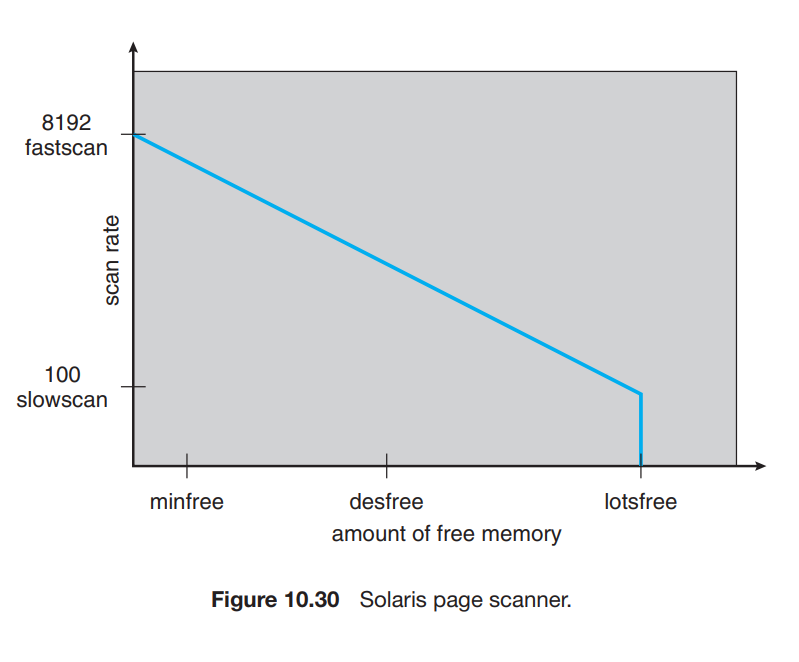

1. **Level 1 - Normal Scanning (Free < `lotsfree`):**
   - `pageout` runs **4 times per second** at a `scanrate` based on how far below `lotsfree` memory is.
2. **Level 2 - Aggressive Scanning (Free < `desfree` - "desired free"):**
   - `pageout` runs **100 times per second** to aggressively reclaim pages and try to keep free memory *above* `desfree`.
   - If it **cannot maintain `desfree` over a 30-second average**, the kernel escalates.
3. **Level 3 - Swapping (Process Termination):**
   - The kernel starts **swapping out entire idle processes** to free all their pages at once. This is a last resort before collapse.
4. **Level 4 - Emergency (Free < `minfree`):**
   - **Every request for a new page** (page fault) triggers the `pageout` scanner synchronously. System performance grinds down as every allocation waits for reclamation.

#### **Optimizations and Special Handling**

- **Reclaim from Free List (Minor Fault):** If a process faults on a page that was recently placed on the free list but not yet reused, Solaris allows it to **reclaim that same page** (a minor fault), avoiding disk I/O.
- **Shared Library Pages:** The scanner **skips pages** belonging to shared libraries (used by many processes), as evicting them would cause major faults in multiple processes.
- **Priority Paging:** Distinguishes between **process pages** and **file system page cache pages**. Under memory pressure, it preferentially reclaims from the **file cache** (which can be re-read from disk) before taking pages from processes. This protects application working sets. (Detailed in **Section 14.6.2**.)

**Summary:** Solaris uses a **dynamic, multi-threshold, two-handed clock algorithm** for global page replacement. Its strength lies in **adaptive aggressiveness** (`scanrate`), a **robust aging mechanism** (two hands), and a **graduated crisis response** from scanning → aggressive scanning → swapping, ensuring system stability under varying loads.

## **10.11 Summary**

#### **Core Concept**

**Virtual Memory** abstracts physical RAM into a vast, uniform logical address space, providing powerful illusions and capabilities to both programmers and processes.

#### **Key Benefits of Virtual Memory**

1. **Larger Than Physical Memory:** Programs can have address spaces larger than available RAM.
2. **Partial Residence:** A program does not need to be entirely loaded in memory to execute.
3. **Memory Sharing:** Processes can share code and data (e.g., shared libraries) efficiently.
4. **Efficient Process Creation:** **Copy-on-Write (COW)** allows fast `fork()` by sharing pages initially and copying only upon modification.

#### **Demand Paging**

The fundamental technique that enables these benefits.

- **Principle:** Load a page into physical memory **only when it is first accessed** (on demand).
- **Page Fault:** The event that occurs when a needed page is not in RAM. The OS handles it by:
  1. Finding a free frame (may require **page replacement**).
  2. Loading the page from disk.
  3. Updating the page table.
  4. Restarting the faulting instruction.

#### **Page Replacement Algorithms**

When no free frames exist, the OS must select a **victim page** to evict. Key algorithms:

- **FIFO (First-In, First-Out):** Simple but suffers from **Belady's Anomaly** (more frames can cause more faults).
- **OPT (Optimal):** Replaces the page used farthest in the future. Theoretically best but unimplementable (needs future knowledge). Serves as a benchmark.
- **LRU (Least Recently Used):** Replaces the page unused for the longest time. Excellent but expensive to implement exactly. It is a **stack algorithm** (no Belady's Anomaly).
- **LRU Approximations (Practical):**
  - **Reference Bit:** Tracks whether a page was used recently.
  - **Second-Chance/Clock Algorithm:** FIFO with a second chance for referenced pages.
  - **Enhanced Second-Chance:** Considers both **reference (R)** and **modify (M)** bits to minimize I/O.

**Scope of Replacement:**

- **Global Replacement:** Victim can be chosen from **any process**. More common, allows dynamic memory flow.
- **Local Replacement:** Victim chosen only from the **faulting process's own frames**. Provides isolation but can be less efficient.

#### **Thrashing and Its Prevention**

- **Thrashing:** A pathological state where the system spends more time **paging than executing** due to severe memory over-commitment.
- **Cause:** Total **working set** sizes of all processes exceed available physical memory.
- **Prevention Strategies:**
  - **Working-Set Model:** Allocate enough frames to hold each process's current locality.
  - **Page-Fault Frequency (PFF):** Dynamically adjust frame allocation to keep a process's page-fault rate within bounds.
  - **Current Practice:** Install **sufficient physical RAM** to accommodate typical working sets.

#### **Memory Compression**

An **alternative to swapping** used prominently in mobile systems (Android, iOS) and modern desktops (Windows, macOS).

- **Action:** Compresses several in-memory pages into a single frame, freeing frames **without disk I/O**.
- **Trade-off:** CPU compression/decompression overhead vs. much faster "paging" within RAM.

#### **Kernel Memory Allocation**

Kernel memory has special needs (small, variable-sized objects; physical contiguity for DMA). Two specialized allocators:

1. **Buddy System:** Allocates **physically contiguous** blocks in **power-of-2 sizes**. Fast coalescing but causes **internal fragmentation**.
2. **Slab Allocation:** Creates **object caches** for each kernel data type. Allocates **exact-size objects** from pre-initialized slabs, achieving **zero fragmentation** and **fast allocation/deallocation**. (Linux uses SLAB, SLOB, SLUB variants).

#### **Performance Considerations**

- **TLB Reach:** Amount of memory mappable by the TLB (= TLB entries × Page Size). Increased via:
  - Larger pages (**Huge Pages**).
  - Multiple page sizes.
  - Hardware support for contiguous blocks (ARMv8 contiguous bit).
- **Program Structure:** Memory access patterns (locality) drastically affect page-fault rates. **Row-major vs. column-major** array traversal is a classic example.
- **I/O Interlock:** Pages involved in **DMA I/O must be locked (pinned)** in memory to prevent data corruption.

#### **Real-World Systems**

- **Linux:** Uses a **two-list (active/inactive)** clock algorithm managed by the **`kswapd`** daemon.
- **Windows:** Uses **clustering** (prepaging), a **hybrid local/global clock algorithm**, and **automatic working-set trimming** under memory pressure.
- **Solaris:** Uses a sophisticated **two-handed clock** algorithm with a **dynamic scan rate** and a multi-tiered response (`lotsfree`, `desfree`, `minfree` thresholds) to memory pressure.

**Virtual memory is the cornerstone of modern system performance and programmability, seamlessly weaving together hardware support, OS algorithms, and application behavior to create the powerful abstraction of abundant, private, fast memory for every process.**